# Maestría en Estadística Aplicada - Análisis Multivariado

Métodos factoriales

Dra. María Inés Stimolo

2021

Componentes principales Ejemplo La base de datos “indice.rda” corresponde a 50 empresas argentinas que cotizan en bolsa con los siguientes indicadores calculados.

LIQACID : Liquidez Acida ((Act.Cte. - Bienes de Cambio)/Pasivo Cte)  
SOLVENC : Solvencia (Activo Total/Pasivo Total)  
PROPACT : Propiedad del Activo (Patrimonio Neto/Activo)  
PNOCOR :Pasivo No Cte./Activo,  
AUTOFIN :Autofinanciación (Utilidades no distribuidas/Activo),  
INMACT :Inmovilización del Activo (Activo no corriente/Activo),  
INMPN :Inmovilización del Patrim. Neto (Activo no corriente/P.Neto),  
RENTECO :Rentabilidad Económica (Utilidad antes de impuestos/Activo Total  
MAREXP :Margen de la Explotación (Utilidad Bruta/Ventas  
REXP_INT :Costo Marginal de Financiamiento (Utilidad Neta/Intereses pagados).

COMPONENTES PRINCIPALES

```r
knitr::opts_chunk$set(echo = TRUE)

load("indice.rda")
dim(indice)
```

```
## [1] 50 12
```

```r
names(indice)
```

```
##  [1] "EMPRESA"  "CONDICIO" "LIQACID"  "SOLVENC"  "PROPACT"  "PNOCOR"
##  [7] "AUTOFIN"  "INMACT"   "INMPN"    "RENTECO"  "MAREXP"   "REXP_INT"
```

```r
 indice=data.frame(indice)

rownames(indice) <-indice$EMPRESA
  #Elimina la  columna (nombre de las empresas)
indice <- indice[,-1]
###Consideramos los 8 primeros indices
indice8=indice[,2:9]

#MATRIZ DE COVARIANZAS
S=cov(indice8) ;S #idem var(X)
```

```
##            LIQACID     SOLVENC     PROPACT       PNOCOR    AUTOFIN      INMACT
## LIQACID 29218.3523  44831.7034  2268.17775  -344.434261  674.28979  -702.50831
## SOLVENC 44831.7034  79418.1360  4409.29066 -1111.590232 1184.07009 -1275.07536
## PROPACT  2268.1778   4409.2907   434.44798   -95.641497  113.05547   -43.66886
## PNOCOR   -344.4343  -1111.5902   -95.64150   153.589337  -74.58429   119.95417
## AUTOFIN   674.2898   1184.0701   113.05547   -74.584293  516.69133   -45.44169
## INMACT   -702.5083  -1275.0754   -43.66886   119.954173  -45.44169   333.52200
## INMPN   -6540.7322 -13027.2730 -1709.65740   462.559459 -559.32513   565.13411
## RENTECO   239.4537    527.7118    94.10779    -4.436059  159.79047   -13.92776
##               INMPN     RENTECO
## LIQACID  -6540.7322  239.453670
## SOLVENC -13027.2730  527.711770
## PROPACT  -1709.6574   94.107788
## PNOCOR     462.5595   -4.436059
## AUTOFIN   -559.3251  159.790469
## INMACT     565.1341  -13.927755
## INMPN    10460.0958 -493.858885
## RENTECO   -493.8589  154.935671
```

```r
#Autovalores y autovectores
eigen=eigen(S);eigen
```

```
## eigen() decomposition
## $values
## [1] 108174.54126   8626.74161   2800.73090    530.65922    351.84968
## [6]    103.19766     68.23986     33.81023
##
## $vectors
##              [,1]        [,2]         [,3]         [,4]         [,5]
## [1,] -0.498122456  0.22226510  0.834576591 -0.002597657  0.012668160
## [2,] -0.852713924  0.04617109 -0.515174074 -0.006199585 -0.009491023
## [3,] -0.047769119 -0.11642880 -0.036134350  0.001352032 -0.238236690
## [4,]  0.011064818  0.03978935  0.077775317 -0.106936292 -0.344040659
## [5,] -0.013340585 -0.04437896  0.018114439  0.941631817 -0.056874044
## [6,]  0.014141290  0.04120603 -0.007213688 -0.062152009 -0.896969847
## [7,]  0.148103297  0.96293307 -0.174119968  0.067155329  0.012103341
## [8,] -0.006010758 -0.04919429  0.004996284  0.305735883 -0.129200188
##              [,6]        [,7]        [,8]
## [1,]  0.039756671  0.06299145 -0.01544061
## [2,] -0.032393882 -0.06238003 -0.01654451
## [3,]  0.122706601  0.65298508  0.69616936
## [4,] -0.576868082 -0.53301033  0.49554943
## [5,]  0.190643102 -0.22296268  0.14684046
## [6,]  0.282544973 -0.01957761 -0.33078290
## [7,] -0.009561752  0.10399333  0.07032205
## [8,] -0.730252332  0.46983086 -0.36516052
```

```r
sum(diag(S))
```

```
## [1] 120689.8
```

```r
VT=sum(eigen$values);VT
```

```
## [1] 120689.8
```

```r
p=nrow(eigen$vectors)
v=c()
for(i in 1:p)
  v[i]=eigen$values[i]/VT*100
v
```

```
## [1] 89.63024860  7.14786479  2.32060339  0.43968865  0.29153231  0.08550655
## [7]  0.05654155  0.02801417
```

```r
#MATRIZ EN DESVIOS
Xdes=scale(indice8, center = TRUE, scale = FALSE)

#C?lculo de las componentes principales
Y=Xdes%*%eigen$vectors ;Y[1:8,1:3]
```

```
##                    [,1]       [,2]      [,3]
##  Bieckert95    97.19859  -28.71339 -22.82952
## CVZA95      -1214.01059   77.26613  56.14423
## Grafex96      169.23994   34.36237 -15.43182
## BOLD96        136.58057   37.87893  60.12042
## alpa_1996    -864.79009   86.66940  94.29805
## GRIM96         15.78169 -100.50946  42.64592
## Gottuz95      -16.26218  -31.57742 111.70439
## REGE95        122.26231  -66.52386 -36.28741
```

```r
Ymed =apply(Y,2,mean)

   #Conservan la variabilidad inicial
     #mostrar con la varianza total
     varTotal= sum(diag(S));varTotal
```

```
## [1] 120689.8
```

```r
     sum(diag(var(Y)))
```

```
## [1] 120689.8
```

```r
     #mostrar con la varianza generalizada
     Vgen= det(S); Vgen
```

```
## [1] 1.161909e+23
```

```r
     det(var(Y))
```

```
## [1] 1.161909e+23
```

Utilizando las funciones prcomp y princomp

```r
#UTILIZANDO EST/ANALISIS DIMENSIONAL, TRABAJANDO CON 8 VARIABLES,
  #MATRIZ DE COVARIANZAS
.PC <- prcomp(indice8);.PC
```

```
## Standard deviations (1, .., p=8):
## [1] 328.898983  92.880254  52.921932  23.036042  18.757656  10.158625   8.260742
## [8]   5.814657
##
## Rotation (n x k) = (8 x 8):
##                  PC1         PC2          PC3          PC4          PC5
## LIQACID  0.498122456 -0.22226510 -0.834576591  0.002597657 -0.012668160
## SOLVENC  0.852713924 -0.04617109  0.515174074  0.006199585  0.009491023
## PROPACT  0.047769119  0.11642880  0.036134350 -0.001352032  0.238236690
## PNOCOR  -0.011064818 -0.03978935 -0.077775317  0.106936292  0.344040659
## AUTOFIN  0.013340585  0.04437896 -0.018114439 -0.941631817  0.056874044
## INMACT  -0.014141290 -0.04120603  0.007213688  0.062152009  0.896969847
## INMPN   -0.148103297 -0.96293307  0.174119968 -0.067155329 -0.012103341
## RENTECO  0.006010758  0.04919429 -0.004996284 -0.305735883  0.129200188
##                  PC6         PC7         PC8
## LIQACID  0.039756671 -0.06299145 -0.01544061
## SOLVENC -0.032393882  0.06238003 -0.01654451
## PROPACT  0.122706601 -0.65298508  0.69616936
## PNOCOR  -0.576868082  0.53301033  0.49554943
## AUTOFIN  0.190643102  0.22296268  0.14684046
## INMACT   0.282544973  0.01957761 -0.33078290
## INMPN   -0.009561752 -0.10399333  0.07032205
## RENTECO -0.730252332 -0.46983086 -0.36516052
```

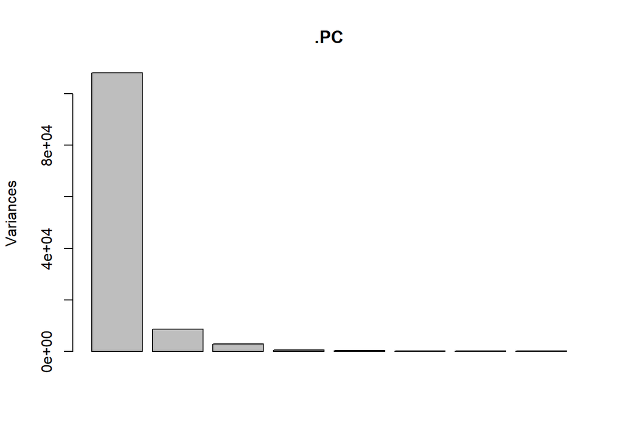

```r
screeplot(.PC)
```

```r
summary(.PC)
```

```
## Importance of components:
##                             PC1      PC2      PC3     PC4      PC5      PC6
## Standard deviation     328.8990 92.88025 52.92193 23.0360 18.75766 10.15862
## Proportion of Variance   0.8963  0.07148  0.02321  0.0044  0.00292  0.00086
## Cumulative Proportion    0.8963  0.96778  0.99099  0.9954  0.99830  0.99915
##                            PC7     PC8
## Standard deviation     8.26074 5.81466
## Proportion of Variance 0.00057 0.00028
## Cumulative Proportion  0.99972 1.00000
```

```r
names(.PC)
```

```
## [1] "sdev"     "rotation" "center"   "scale"    "x"
```

```r
.PC$sdev #desviaci?n est?ndar de las componentes
```

```
## [1] 328.898983  92.880254  52.921932  23.036042  18.757656  10.158625   8.260742
## [8]   5.814657
```

```r
.PC$center# las medias de las variables
```

```
##    LIQACID    SOLVENC    PROPACT     PNOCOR    AUTOFIN     INMACT      INMPN
## 118.184418 293.521467  51.138574  11.801264  -2.437780  61.613622 153.246871
##    RENTECO
##  -4.304843
```

```r
.PC$sd^2  # component variances
```

```
## [1] 108174.54126   8626.74161   2800.73090    530.65922    351.84968
## [6]    103.19766     68.23986     33.81023
```

```r
varcomp=sum(.PC$sd^2 ); varcomp
```

```
## [1] 120689.8
```

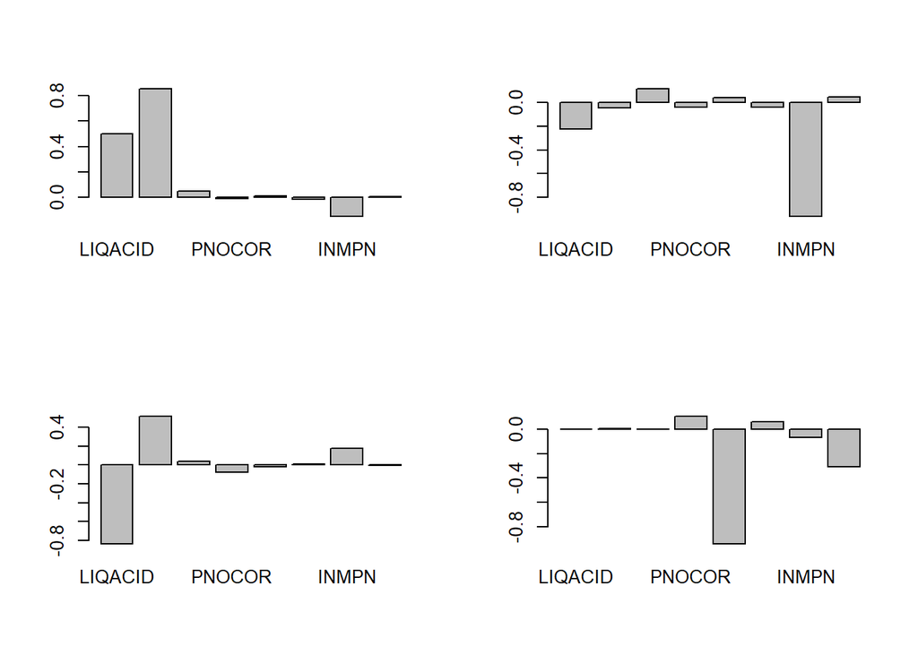

```r
#gr?fico de los 4 primeras vectores propios
U=.PC$rotation
par(mfrow=c(2,2))
barplot(U[,1])
barplot(U[,2])
barplot(U[,3])
barplot(U[,4])
```

```r
#componenete 1
.PC$x[,1]
```

```
##   Bieckert95       CVZA95     Grafex96       BOLD96    alpa_1996       GRIM96
##  -97.1985858 1214.0105899 -169.2399396 -136.5805695  864.7900851  -15.7816857
##     Gottuz95       REGE95     Bonafi93      CINZ 93    Panizza95       MIDL95
##   16.2621790 -122.2623055 -199.2564597  413.7224871 -177.0980537 1424.9738949
##    plav_1992       HULI92     casaam93       pata93    deck_1995       TEME95
##  -75.1353482 -109.4736012 -139.2231167  -56.5289398 -216.1285765  142.6875651
##    gras_1993       GRIE93    hali_1997       CTBA97       acec94       LEID94
## -135.5661929    0.9875263   59.8152246 -144.4828192 -117.2390453   45.8145976
##     neroli94       EMAC94      Drago92      DOMEC92     Canale92       ESME92
##  -99.6646995 -119.1979531  -45.3666198  270.3722173 -211.4421340  -88.4353758
##       colo93       QUES93    indu_1994       ASTR94    masu_1997       ESTR97
## -144.2692665   69.6429199  -98.1586661  -28.3070396  -33.1150439  -83.7462014
##    zane_1992       PERK92      SEVEL97       RENO97    prot_1995       DICA94
## -129.1914114 -110.0267633 -189.1576730 -129.7676717 -183.4513217  112.8782925
##    baes_1995       DICO95   IN_DE_CO92       EMAC92      Azuca93       TABA93
## -130.5718743 -201.8092570  -76.9129164  -71.0816085 -201.5620787 -214.8377682
##     Galimb95       LEID95
## -266.6866602  131.9976638
```

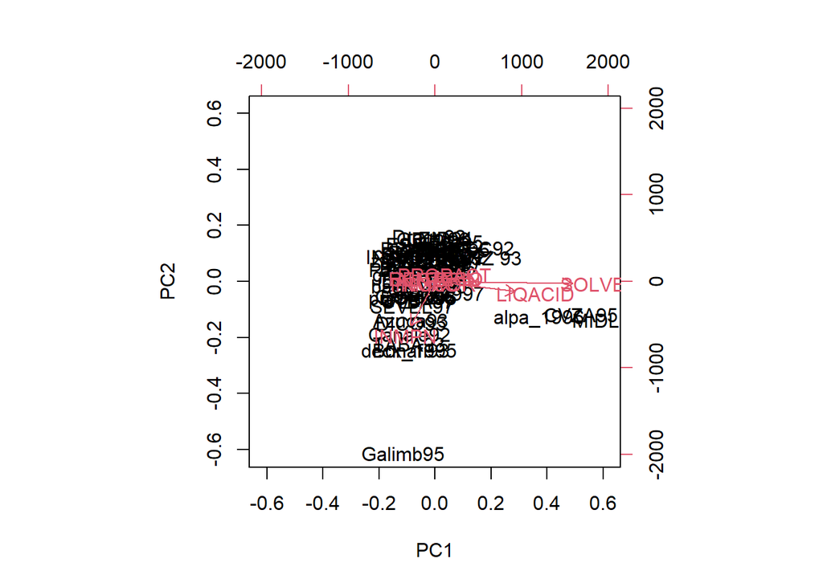

```r
#guardar las componentes
#indice8$PC1 <- .PC$x[,1]
#indice8$PC2 <- .PC$x[,2]
#indice8$PC3 <- .PC$x[,3]
par(mfrow=c(1,1))
#biplot de las dos primeras componentes
biplot(.PC)
```

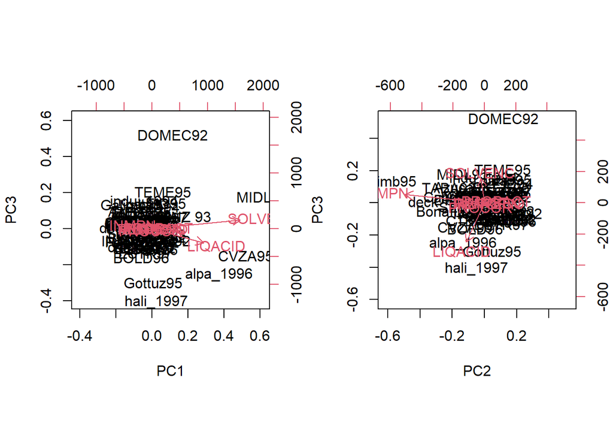

```r
par(mfrow=c(1,2))
#biplot de las con  otras componentes
biplot(.PC,choices=c(1,3))
biplot(.PC,choices=c(2,3))
```

```r
  #MATRIZ DE CORRELACION
.PCC <- prcomp(indice8[,1:8], scale.=TRUE);.PCC
```

```
## Standard deviations (1, .., p=8):
## [1] 1.8832918 1.1873840 1.1347382 0.8810697 0.7499120 0.5441775 0.2848411
## [8] 0.1994616
##
## Rotation (n x k) = (8 x 8):
##                PC1         PC2         PC3          PC4         PC5         PC6
## LIQACID  0.4066616 -0.33730840  0.27459928 -0.392319151 -0.12657411  0.05065719
## SOLVENC  0.4488227 -0.31739958  0.20661053 -0.272891086  0.02256626 -0.16243702
## PROPACT  0.4707535 -0.04506159  0.20654779  0.352932570  0.17499550 -0.05798534
## PNOCOR  -0.2834399  0.03282230  0.61313133 -0.031301447 -0.55767140  0.40525933
## AUTOFIN  0.2346428  0.58856907 -0.03965134 -0.487847496  0.31437448  0.49594412
## INMACT  -0.2245798  0.10110868  0.65866380  0.158300022  0.62116968 -0.13739064
## INMPN   -0.4129050 -0.10504403  0.02303799 -0.618854019  0.10543128 -0.44615149
## RENTECO  0.2350606  0.64397355  0.16545191  0.006370672 -0.38216503 -0.58272011
##                PC7          PC8
## LIQACID -0.4366081 -0.531334598
## SOLVENC  0.1190828  0.734562773
## PROPACT  0.6672512 -0.360454298
## PNOCOR   0.2481320  0.069805064
## AUTOFIN  0.1170037  0.021909613
## INMACT  -0.2707878  0.048888284
## INMPN    0.4294145 -0.200998458
## RENTECO -0.1303314 -0.005527483
```

```r
screeplot(.PCC)
summary(.PCC)
```

```
## Importance of components:
##                           PC1    PC2    PC3     PC4    PC5     PC6     PC7
## Standard deviation     1.8833 1.1874 1.1347 0.88107 0.7499 0.54418 0.28484
## Proportion of Variance 0.4434 0.1762 0.1610 0.09704 0.0703 0.03702 0.01014
## Cumulative Proportion  0.4434 0.6196 0.7805 0.87757 0.9479 0.98489 0.99503
##                            PC8
## Standard deviation     0.19946
## Proportion of Variance 0.00497
## Cumulative Proportion  1.00000
```

```r
.PCC$sdev #desviaci?n est?ndar de las componentes
```

```
## [1] 1.8832918 1.1873840 1.1347382 0.8810697 0.7499120 0.5441775 0.2848411
## [8] 0.1994616
```

```r
.PCC$center# las medias de las variables
```

```
##    LIQACID    SOLVENC    PROPACT     PNOCOR    AUTOFIN     INMACT      INMPN
## 118.184418 293.521467  51.138574  11.801264  -2.437780  61.613622 153.246871
##    RENTECO
##  -4.304843
```

```r
.PCC$scale
```

```
##   LIQACID   SOLVENC   PROPACT    PNOCOR   AUTOFIN    INMACT     INMPN   RENTECO
## 170.93377 281.81224  20.84342  12.39312  22.73085  18.26258 102.27461  12.44732
```

```r
## .PCC$x para encontrar las componentes

.PCC$sd^2  # component variances
```

```
## [1] 3.54678810 1.40988079 1.28763069 0.77628379 0.56236804 0.29612919 0.08113447
## [8] 0.03978492
```

```r
varcomp=sum(.PCC$sd^2 ); varcomp
```

```
## [1] 8
```

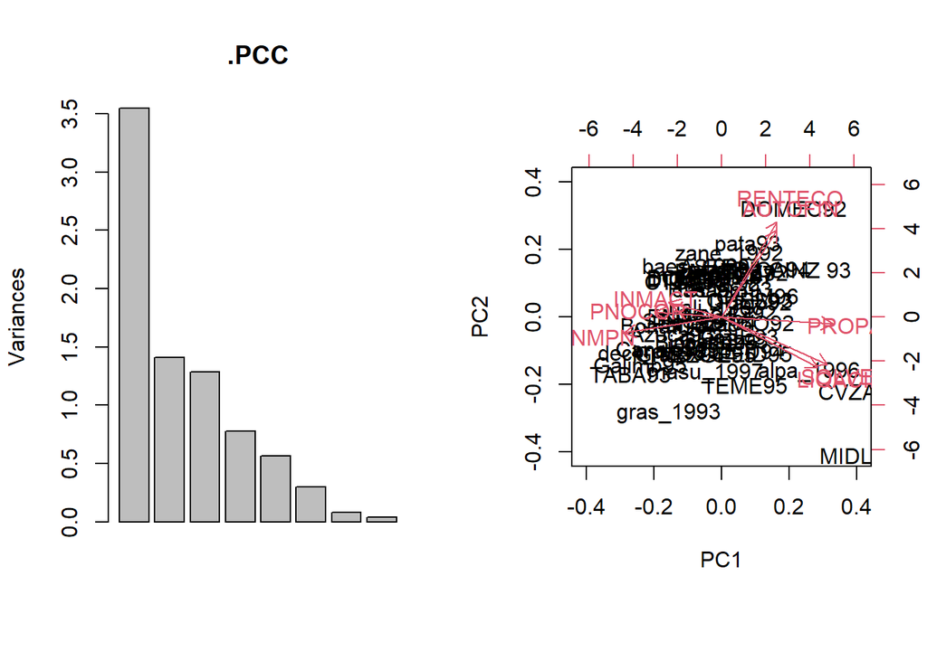

```r
#gr?fico de los 4 primeras vectores propios
U=.PCC$rotation
biplot(.PCC)
```

```r
#Covarianza entre comp. princ. y variables originales estandarizadas

Sd=diag(.PCC$sd^2)

CovZ_Y=U%*%Sd;CovZ_Y
```

```
##               [,1]        [,2]        [,3]        [,4]        [,5]        [,6]
## LIQACID  1.4423427 -0.47556464  0.35358246 -0.30455100 -0.07118123  0.01500107
## SOLVENC  1.5918791 -0.44749557  0.26603806 -0.21184093  0.01269054 -0.04810234
## PROPACT  1.6696631 -0.06353146  0.26595728  0.27397583  0.09841187 -0.01717115
## PNOCOR  -1.0053012  0.04627554  0.78948672 -0.02429881 -0.31361657  0.12000912
## AUTOFIN  0.8322284  0.82981223 -0.05105628 -0.37870810  0.17679416  0.14686353
## INMACT  -0.7965368  0.14255119  0.84811572  0.12288574  0.34932597 -0.04068538
## INMPN   -1.4644867 -0.14809956  0.02966443 -0.48040634  0.05929118 -0.13211848
## RENTECO  0.8337102  0.90792594  0.21304095  0.00494545 -0.21491740 -0.17256043
##                 [,7]          [,8]
## LIQACID -0.035423970 -0.0211391061
## SOLVENC  0.009661719  0.0292245234
## PROPACT  0.054137072 -0.0143406465
## PNOCOR   0.020132055  0.0027771891
## AUTOFIN  0.009493033  0.0008716723
## INMACT  -0.021970227  0.0019450166
## INMPN    0.034840321 -0.0079967082
## RENTECO -0.010574367 -0.0002199105
```

```r
#Correlacion
#matriz diagonal con los valores  propios
Ds=diag(.PCC$sd)
#correlaci?n entre las variables originales y las componentes al cuadrado
CorZ_Y_2=(U%*%Ds)^2;CorZ_Y_2
```

```
##              [,1]        [,2]         [,3]         [,4]         [,5]
## LIQACID 0.5865454 0.160411948 0.0970934890 1.194812e-01 0.0090097015
## SOLVENC 0.7144716 0.142034906 0.0549662636 5.780950e-02 0.0002863781
## PROPACT 0.7859998 0.002862828 0.0549328881 9.669500e-02 0.0172216346
## PNOCOR  0.2849424 0.001518870 0.4840590432 7.605878e-04 0.1748949896
## AUTOFIN 0.1952764 0.488401808 0.0020244496 1.847518e-01 0.0555795709
## INMACT  0.1788860 0.014413163 0.5586231211 1.945282e-02 0.2169907030
## INMPN   0.6046940 0.015556975 0.0006834089 2.973014e-01 0.0062511455
## RENTECO 0.1959724 0.584680297 0.0352480315 3.150584e-05 0.0821339125
##                 [,6]        [,7]         [,8]
## LIQACID 0.0007599121 0.015466393 1.123194e-02
## SOLVENC 0.0078136018 0.001150544 2.146725e-02
## PROPACT 0.0009956751 0.036123025 5.169148e-03
## PNOCOR  0.0486348146 0.004995406 1.938619e-04
## AUTOFIN 0.0728361048 0.001110720 1.909800e-05
## INMACT  0.0055897903 0.005949270 9.508852e-05
## INMPN   0.0589448575 0.014960940 1.607326e-03
## RENTECO 0.1005544343 0.001378172 1.215551e-06
```

```r
sumfil=c()
for (i in 1:8)
sumfil[i]=sum(CorZ_Y_2[i,])
sumfil
```

```
## [1] 1 1 1 1 1 1 1 1
```

```r
sumcol=c()
for (i in 1:8)
sumcol[i]=sum(CorZ_Y_2[,i])
sumcol
```

```
## [1] 3.54678810 1.40988079 1.28763069 0.77628379 0.56236804 0.29612919 0.08113447
## [8] 0.03978492
```

```r
#Ejercicio: Calcular las componentes utilizando la funci?n "princomp"
```

Componentes principales robustas

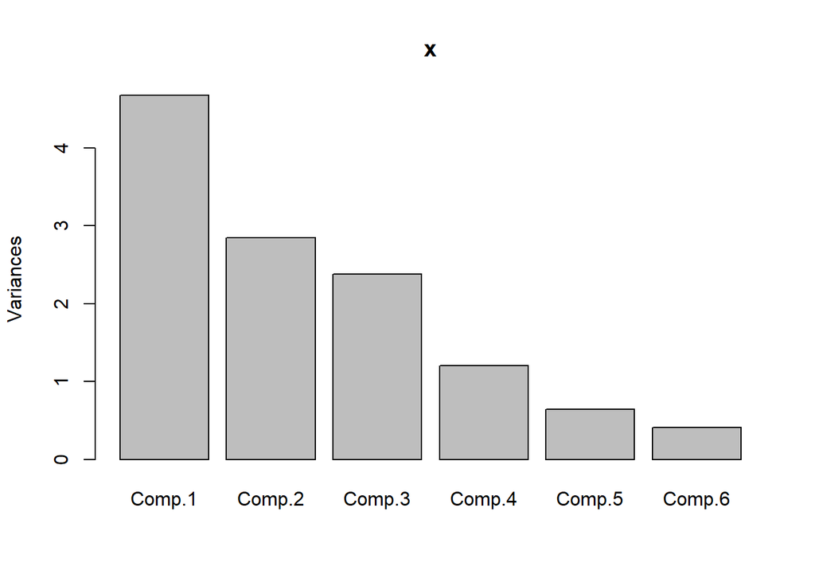

```r
library(pcaPP)
x<-PCAproj(indice8,k = 6,method="mad",CalcMethod="eachobs",center=l1median_NLM,scale="mad")

screeplot(x)
```

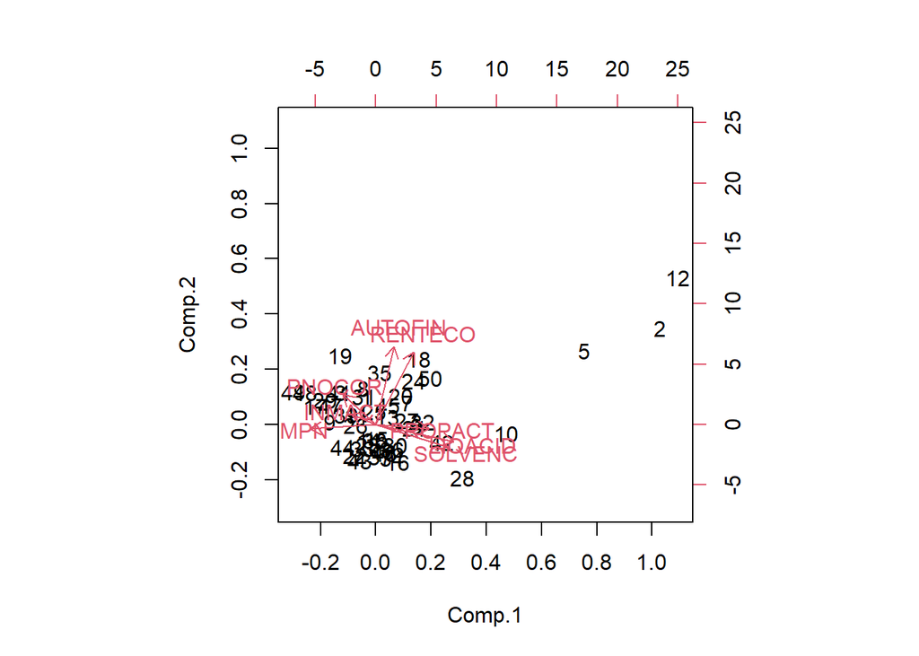

```r
biplot(x)
```

```r
#biplot(x,xlabs=as.character(data8$G2))

summary(x)
```

```
## Importance of components:
##                           Comp.1    Comp.2    Comp.3     Comp.4     Comp.5
## Standard deviation     2.1620434 1.6866369 1.5421897 1.09688306 0.80138167
## Proportion of Variance 0.3847532 0.2341513 0.1957623 0.09903165 0.05286061
## Cumulative Proportion  0.3847532 0.6189045 0.8146667 0.91369837 0.96655898
##                            Comp.6
## Standard deviation     0.63740145
## Proportion of Variance 0.03344102
## Cumulative Proportion  1.00000000
```

```r
x$loadings
```

```
##
## Loadings:
##         Comp.1 Comp.2 Comp.3 Comp.4 Comp.5 Comp.6
## LIQACID  0.525 -0.149  0.287 -0.555  0.134 -0.166
## SOLVENC  0.487 -0.198  0.315  0.169  0.384  0.163
## PROPACT  0.361                0.468
## PNOCOR  -0.223  0.263  0.752 -0.158 -0.349 -0.262
## AUTOFIN  0.123  0.679 -0.236         0.473 -0.442
## INMACT  -0.164         0.370  0.592  0.293 -0.176
## INMPN   -0.446         0.219 -0.249  0.591  0.470
## RENTECO  0.257  0.630               -0.223  0.654
##
##                Comp.1 Comp.2 Comp.3 Comp.4 Comp.5 Comp.6
## SS loadings     1.000  1.000  1.000  1.000  1.000  1.000
## Proportion Var  0.125  0.125  0.125  0.125  0.125  0.125
## Cumulative Var  0.125  0.250  0.375  0.500  0.625  0.750
```

```r
x$center
```

```
## [1]  70.539416 216.141492  49.284907  13.014778  -1.557516  65.272235 144.957868
## [8]  -4.016426
```

```r
#x$scores (para encontrar las componentes)
```

Componentes principales comunes

```r
library(multigroup)
#definir la variable grupo
 Group = as.factor(indice$CONDICIO)#calcular componentes principales robustas
 #calcular componentes principales robustas
res.FCPCA = FCPCA(indice[,3:10], Group,  Scale =FALSE)
res.FCPCA
```

```
## $Data
##     SOLVENC   PROPACT      PNOCOR     AUTOFIN    INMACT     INMPN     RENTECO
## 1  221.0182 54.754851 10.97457097 -21.3471134  77.94299 142.34902 -12.7824997
## 2 1303.3462 92.327441  0.45341514  17.2020371  35.45350  38.39974   0.3362886
## 1  158.8491 37.047169 10.95871795 -20.3693823  78.52363 211.95581 -20.3693823
## 2  149.0278 32.898407 38.37571227   5.6740573  65.61972 199.46170   5.7847071
## 1  985.6998 89.854923  7.54421241   1.3017814  82.85660  92.21153   1.3017814
## 2  252.7377 60.433281  0.00000000  11.2274407  32.15251  53.20332   0.7043814
## 1  248.1759 59.705998 23.77620839 -15.9176747  60.10508 100.66842  -7.1671783
## 2  204.6905 51.145744  0.01574048   0.0000000  57.45275 112.33144 -29.0555966
## 1  121.4605 17.668683 24.39623558 -14.0976766  59.17102 334.89210  -6.0345233
## 2  656.4171 84.765784  0.25724412  32.4641809  39.24313  46.29596  17.9300737
## 1  128.0792 21.923305  8.61413412  -7.0873643  31.80953 145.09458  -9.2900022
## 2 1548.1891 93.540841  0.46609472   0.0000000  34.99640  37.41297 -16.2214337
## 1  210.7389 52.547917  7.68697127   0.0000000  54.54573 103.80188  -6.8149076
```

[output cut: 349 more lines]

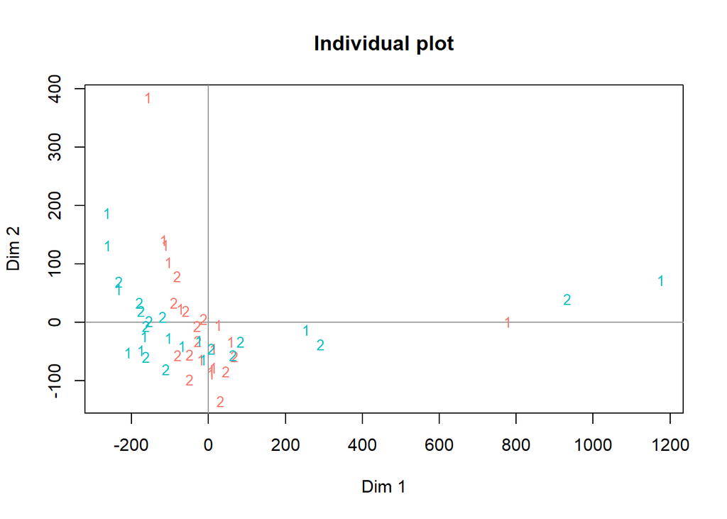

```r
# Grafico de los dos primeros ejes
  scoreplot(res.FCPCA, axes=c(1,2))
```

```r
summary(res.FCPCA)
```

```
##                 Length Class  Mode
## Data            400    -none- numeric
## Con.Data        400    -none- numeric
## split.Data        2    -none- list
## Group            50    factor numeric
## loadings.common  64    -none- numeric
## lambda           16    -none- numeric
## exp.var          16    -none- numeric
```

```r
  names(res.FCPCA)
```

```
## [1] "Data"            "Con.Data"        "split.Data"      "Group"
## [5] "loadings.common" "lambda"          "exp.var"
```

```r
  res.FCPCA$exp.var
```

```
##       Dim1      Dim2      Dim3      Dim4      Dim5       Dim6       Dim7
## 1 68.73006 26.761187 1.1975332 1.3148785 1.6343105 0.18228656 0.07942869
## 2 95.84059  3.237963 0.4810663 0.1536811 0.1005221 0.08696633 0.08706634
##         Dim8
## 1 0.10031681
## 2 0.01214267
```

```r
  res.FCPCA$lambda
```

```
##        Dim1     Dim2    Dim3    Dim4    Dim5    Dim6    Dim7   Dim8
## 1  28616.51 11142.31 498.606 547.464 680.463  75.897  33.071 41.768
## 2 117872.26  3982.30 591.653 189.009 123.630 106.958 107.081 14.934
```

```r
  res.FCPCA$loadings.common
```

```
##                  Dim1        Dim2         Dim3         Dim4         Dim5
## SOLVENC  0.9906096203  0.13119348  0.004715859  0.003626732 -0.007367002
## PROPACT  0.0477614828 -0.09996235 -0.010619715  0.260126415 -0.013239226
## PNOCOR  -0.0183528893  0.04504035  0.111637144  0.324686588 -0.218394979
## AUTOFIN  0.0091057033 -0.03194034 -0.918055865  0.026273380  0.250831559
## INMACT  -0.0203194792  0.08059193 -0.020750874  0.899201363 -0.022377091
## INMPN   -0.1247849857  0.98039078 -0.052531572 -0.062360718 -0.009851790
## RENTECO  0.0027375109 -0.03545291 -0.277255338  0.066724312 -0.052345306
## MAREXP  -0.0001032974 -0.02879102 -0.253997781 -0.096464193 -0.941179998
##                Dim6         Dim7        Dim8
## SOLVENC -0.02797506 -0.005862471 -0.02396274
## PROPACT  0.59397771  0.190822677  0.72838846
## PNOCOR  -0.74994196 -0.058487932  0.51596526
## AUTOFIN -0.09543970 -0.261172262  0.12306048
## INMACT   0.13573356 -0.103446622 -0.39303032
## INMPN    0.08267903  0.053398881  0.08264304
## RENTECO -0.16849521  0.930906031 -0.14034328
## MAREXP   0.14572625 -0.108544308 -0.08070351
```

ESCALAMIENTO MULTIDIMENSIONAL

```r
library(readxl)
datos_espania <- read_excel("datos_espania.xls")

Datos=as.data.frame(datos_espania)
rownames(Datos)=Datos[,1]
Datos=Datos[,-1];
Datos
```

```
##      M    B   V    S  SS   LC
## M    0  627 351  550 488  603
## B  627    0 361 1043 565 1113
## V  351  361   0  567 564  954
## S  550 1043 567    0 971  950
## SS 488  565 564  971   0  713
## LC 603 1113 954  950 713    0
```

```r
 n=nrow(Datos);n
```

```
## [1] 6
```

```r
In=diag(1,n)
unos=rep(1,n)
P=In-(1/n)*(unos%*%t(unos));P
```

```
##            [,1]       [,2]       [,3]       [,4]       [,5]       [,6]
## [1,]  0.8333333 -0.1666667 -0.1666667 -0.1666667 -0.1666667 -0.1666667
## [2,] -0.1666667  0.8333333 -0.1666667 -0.1666667 -0.1666667 -0.1666667
## [3,] -0.1666667 -0.1666667  0.8333333 -0.1666667 -0.1666667 -0.1666667
## [4,] -0.1666667 -0.1666667 -0.1666667  0.8333333 -0.1666667 -0.1666667
## [5,] -0.1666667 -0.1666667 -0.1666667 -0.1666667  0.8333333 -0.1666667
## [6,] -0.1666667 -0.1666667 -0.1666667 -0.1666667 -0.1666667  0.8333333
```

```r
dim(P)
```

```
## [1] 6 6
```

```r
 Q=(-0.5)*(P%*%(as.matrix(Datos^2))%*%P); Q
```

```
##           [,1]       [,2]       [,3]       [,4]       [,5]       [,6]
## [1,]  11759.44  -39079.22  -17954.39   38559.11  -31804.89   38519.94
## [2,] -39079.22  303211.11  124211.44 -208389.56   73380.44 -253334.22
## [3,] -17954.39  124211.44   75532.78   60951.28  -39894.22 -202846.89
## [4,]  38559.11 -208389.56   60951.28  367858.78 -206103.72  -52875.89
## [5,] -31804.89   73380.44  -39894.22 -206103.72  162774.78   41647.61
## [6,]  38519.94 -253334.22 -202846.89  -52875.89   41647.61  428889.44
```

```r
 #c?lculo de las dos primeras coordenadas
  eigen=eigen(Q);eigen
```

```
## eigen() decomposition
## $values
## [1]  7.379169e+05  5.910588e+05  5.946873e+04  1.035536e+03  7.275958e-11
## [6] -3.945367e+04
##
## $vectors
##            [,1]        [,2]         [,3]        [,4]      [,5]        [,6]
## [1,]  0.0959729 -0.04429354  0.256942195  0.85659994 0.4082483  0.14959236
## [2,] -0.6270080  0.14004992  0.415521275 -0.15933263 0.4082483 -0.47173675
## [3,] -0.2832133 -0.25835017  0.009409856 -0.31296904 0.4082483  0.76703361
## [4,]  0.2934011 -0.72163136 -0.220480281 -0.12846516 0.4082483 -0.40172434
## [5,] -0.1240990  0.44165813 -0.781233037  0.08849908 0.4082483 -0.06865662
## [6,]  0.6449462  0.44256702  0.319839993 -0.34433219 0.4082483  0.02549174
```

```r
Y=eigen$vectors[,1:2]%*%diag(sqrt(eigen$values[1:2]));Y
```

```
##            [,1]       [,2]
## [1,]   82.44273  -34.05303
## [2,] -538.61294  107.67087
## [3,] -243.28619 -198.62051
## [4,]  252.03769 -554.79271
## [5,] -106.60360  339.54831
## [6,]  554.02232  340.24707
```

```r
  k=2
  MD=cmdscale(Datos,k=k,eig=T, x.ret = TRUE);MD
```

```
## $points
##          [,1]       [,2]
## M    82.44273  -34.05303
## B  -538.61294  107.67087
## V  -243.28619 -198.62051
## S   252.03769 -554.79271
## SS -106.60360  339.54831
## LC  554.02232  340.24707
##
## $eig
## [1]  7.379169e+05  5.910588e+05  5.946873e+04  1.035536e+03  1.236913e-10
## [6] -3.945367e+04
##
## $x
##            M          B          V          S         SS         LC
## M  -23518.89   78158.44   35908.78  -77118.22   63609.78  -77039.89
## B   78158.44 -606422.22 -248422.89  416779.11 -146760.89  506668.44
## V   35908.78 -248422.89 -151065.56 -121902.56   79788.44  405693.78
## S  -77118.22  416779.11 -121902.56 -735717.56  412207.44  105751.78
## SS  63609.78 -146760.89   79788.44  412207.44 -325549.56  -83295.22
## LC -77039.89  506668.44  405693.78  105751.78  -83295.22 -857778.89
##
## $ac
## [1] 0
##
## $GOF
## [1] 0.9300472 0.9564555
```

```r
 #  Calculamos los autovalores
 MD$eig
```

```
## [1]  7.379169e+05  5.910588e+05  5.946873e+04  1.035536e+03  1.236913e-10
## [6] -3.945367e+04
```

```r
 # Normalizo los dos primeros autovalores
 sum(abs(MD$eig[1:k]))/sum(abs(MD$eig))
```

```
## [1] 0.9300472
```

```r
 MD$GOF
```

```
## [1] 0.9300472 0.9564555
```

```r
##La solución con dos dimensiones es adecuada
# Se muestran las coordenadas de las ciudades en las dos dimensiones
 MD$points[,1:2]
```

```
##          [,1]       [,2]
## M    82.44273  -34.05303
## B  -538.61294  107.67087
## V  -243.28619 -198.62051
## S   252.03769 -554.79271
## SS -106.60360  339.54831
## LC  554.02232  340.24707
```

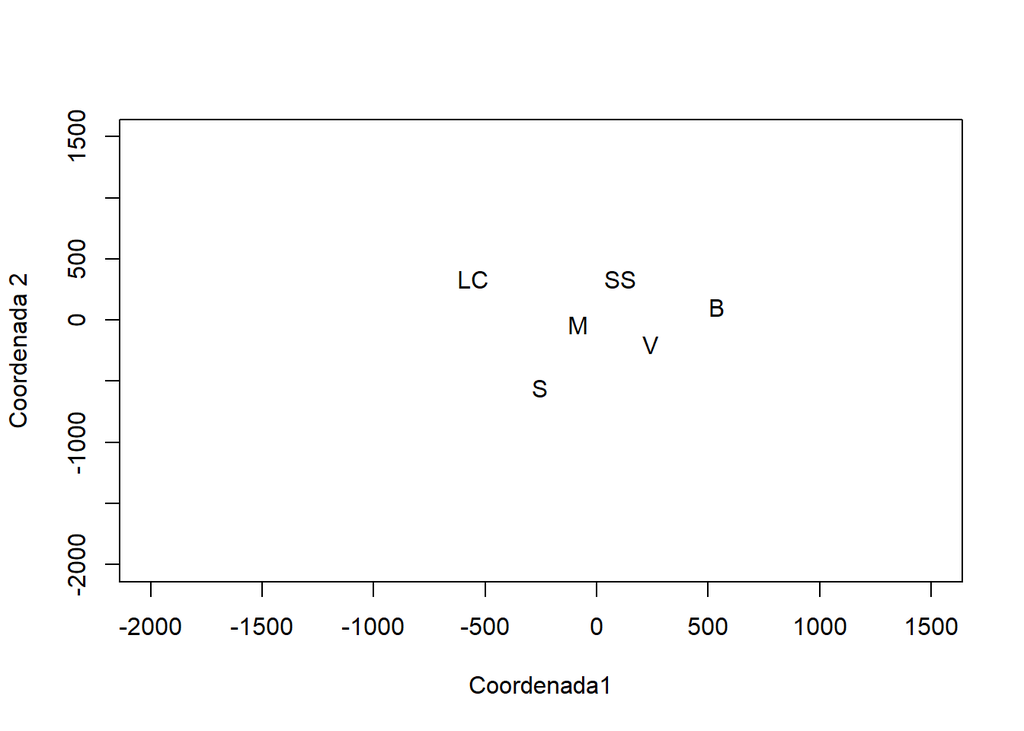

```r
 # Se dibujan las coordenadas de las ciudades en las dos dimensiones

plot(-MD$points[,1],MD$points[,2],type="n",xlab="Coordenada1",ylab="Coordenada 2",
     xlim = c(-2000,1500),ylim=c(-2000,1500))
text(-MD$points[,1],MD$points[,2],labels=row.names(Datos))
```

```r
###Ejmeplo de los productos de Pe?a


load("productos.RData")

prod=as.data.frame(productos)
rownames(prod)=prod[,1]
prod=prod[,-1]
library(MASS)
 #help(isoMDS)
k=2
prod.mds = isoMDS(as.matrix(prod),k=k,p=2)##p potencia de Minkowki,k= coordendas
names(prod.mds)
```

```
## [1] "points" "stress"
```

```r
prod.mds$points
```

```
##         [,1]       [,2]
## A  6.1365452  1.8289088
## B  1.3142377 -4.5569073
## C  2.3287162 -0.8903469
## D -1.8105626  1.2392767
## E -0.6958321 -2.1193530
## F -1.8422913  4.2480542
## G -5.4308132  0.2503675
```

```r
prod.mds$stress
```

```
## [1] 7.08601
```

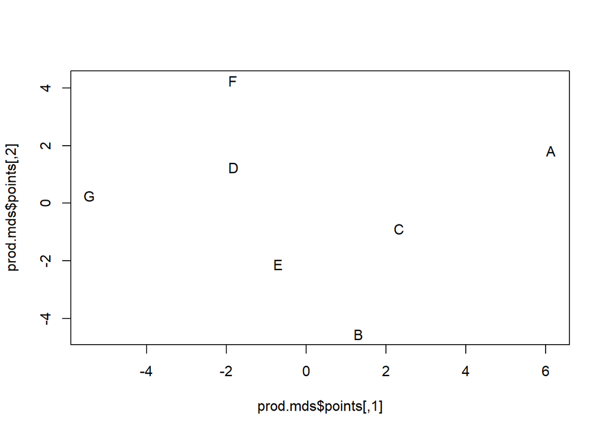

```r
plot(prod.mds$points, type = "n")
text(prod.mds$points, labels = as.character(rownames(prod)))
```

```r
MDprod=cmdscale(prod,k=k,eig=T);MDprod
```

```
## $points
##         [,1]        [,2]
## A  5.3653128  2.10386005
## B  1.3884389 -3.58622610
## C  1.1638928 -0.81833285
## D -3.2507539 -0.24452185
## E  0.4520411 -0.02609855
## F -1.5654748  1.50797637
## G -3.5534569  1.06334294
##
## $eig
## [1]  5.791850e+01  2.142208e+01  1.219826e+01  8.714724e+00  4.137911e-01
## [6] -5.329071e-15 -1.166735e+01
##
## $x
## NULL
##
## $ac
## [1] 0
##
## $GOF
## [1] 0.7062874 0.7881461
```

```r
sum(abs(MDprod$eig[1:2]))/sum(abs(MDprod$eig))
```

```
## [1] 0.7062874
```

```r
sum(MDprod$eig[1:2]^2)/sum(MDprod$eig^2)
```

```
## [1] 0.9135125
```

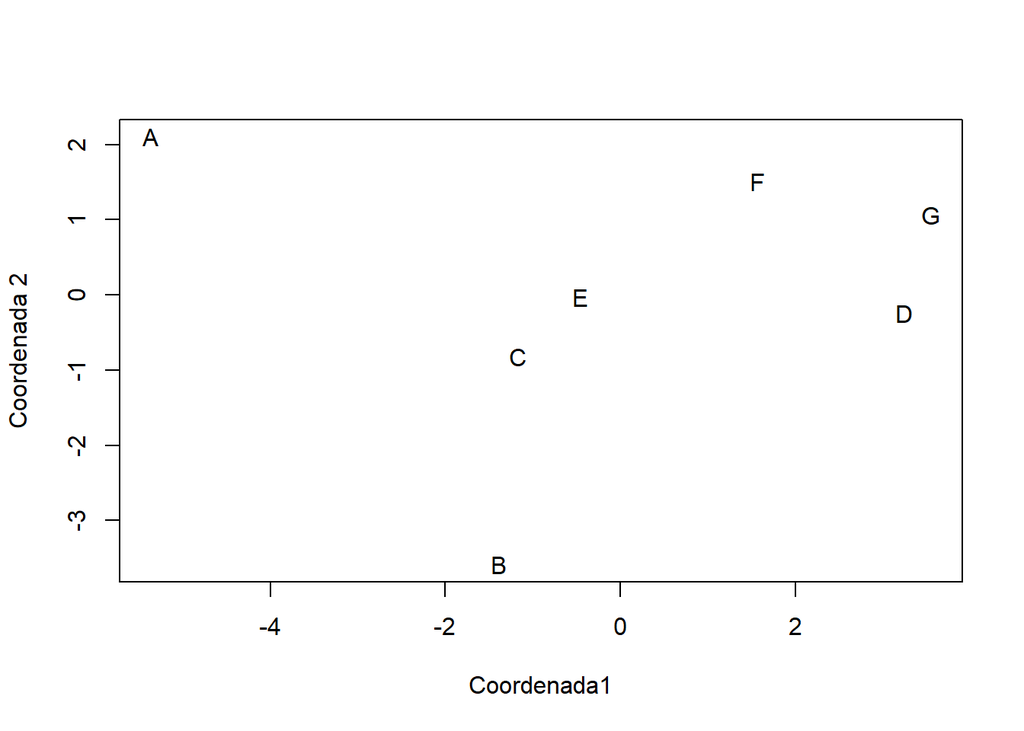

```r
 #La solución con dos dimensiones es adecuada
 # Se muestran las coordenadas de los productos en las dos dimensiones
#MDprod$points[,1:2]

 # Se dibujan las coordenadas de los productos en las dos dimensiones

plot(-MDprod$points[,1],MDprod$points[,2],type="n",xlab="Coordenada1",ylab="Coordenada 2")
text(-MDprod$points[,1],MDprod$points[,2],labels=row.names(prod))
```

ANALISIS DE CORRESPONDENCIA

ANALISIS DE CORRESPONDENCIA SIMPLE

```r
x=read.table("eph.dat",header=TRUE)
dim(x)
```

```
## [1] 282   4
```

```r
names(x)
```

```
## [1] "SEXO"     "ESTCIV"   "NIVEL_ED" "ESTADO"
```

```r
#SEXO 'Sexo'
#1 = var?n  2 = mujer

#ESTCIV Estado Civil
#1 = unido  2 = casado  3 = separado/a ? divorciado  4 = viudo  5 = soltero

#NIVEL_ED   'M?ximo Nivel Educativo Alcanzado'
#1 = Primaria 2 Secundaria 3= Superior Universitaria

#ESTADO 'Condici?n de Actividad'
#1 = Ocupado    2 = Desocupado  3 = Inactivo

#seleccionamos variables estado Civil y educacion y las definimos como factor
ESTCIVIL=x[,2]
EDUC=x[,3]

EDUC=factor(EDUC)
levels(EDUC)=c("Primario", "Secund.", "TerciarioUniv.")

ESTCIVIL=factor(ESTCIVIL)
levels(ESTCIVIL)=c("unido", "casado", "separado","viudo","soltero")

#generamos una tabla a partir de estas variables
T=table(ESTCIVIL,EDUC)
T
```

```
##           EDUC
## ESTCIVIL   Primario Secund. TerciarioUniv.
##   unido          17       9              6
##   casado         55      44             39
##   separado       11      16              9
##   viudo          35       3              4
##   soltero         8       7             19
```

```r
X=as.matrix(T);X
```

```
##           EDUC
## ESTCIVIL   Primario Secund. TerciarioUniv.
##   unido          17       9              6
##   casado         55      44             39
##   separado       11      16              9
##   viudo          35       3              4
##   soltero         8       7             19
```

```r
di=dim(X);di
```

```
## [1] 5 3
```

```r
f=di[1];f
```

```
## [1] 5
```

```r
c=di[2];c
```

```
## [1] 3
```

```r
n=sum(X);n
```

```
## [1] 282
```

```r
 #matriz de frecuencias relativas#

F=(1/n)*X;F
```

```
##           EDUC
## ESTCIVIL     Primario    Secund. TerciarioUniv.
##   unido    0.06028369 0.03191489     0.02127660
##   casado   0.19503546 0.15602837     0.13829787
##   separado 0.03900709 0.05673759     0.03191489
##   viudo    0.12411348 0.01063830     0.01418440
##   soltero  0.02836879 0.02482270     0.06737589
```

```r
#frecuencias relativas marginales por fila
unos=rep(1,c);unos
```

```
## [1] 1 1 1
```

```r
sf=c(F%*%unos);sf
```

```
## [1] 0.1134752 0.4893617 0.1276596 0.1489362 0.1205674
```

```r
Df=diag(sf);Df
```

```
##           [,1]      [,2]      [,3]      [,4]      [,5]
## [1,] 0.1134752 0.0000000 0.0000000 0.0000000 0.0000000
## [2,] 0.0000000 0.4893617 0.0000000 0.0000000 0.0000000
## [3,] 0.0000000 0.0000000 0.1276596 0.0000000 0.0000000
## [4,] 0.0000000 0.0000000 0.0000000 0.1489362 0.0000000
## [5,] 0.0000000 0.0000000 0.0000000 0.0000000 0.1205674
```

```r
#matriz frecuencias elativas condicionadas por fila.
PF=solve(Df)%*%F; PF
```

```
##       EDUC
##         Primario    Secund. TerciarioUniv.
##   [1,] 0.5312500 0.28125000      0.1875000
##   [2,] 0.3985507 0.31884058      0.2826087
##   [3,] 0.3055556 0.44444444      0.2500000
##   [4,] 0.8333333 0.07142857      0.0952381
##   [5,] 0.2352941 0.20588235      0.5588235
```

```r
PFsum=PF%*%unos;PFsum   ##control de suma filas
```

```
##      [,1]
## [1,]    1
## [2,]    1
## [3,]    1
## [4,]    1
## [5,]    1
```

```r
#frecuencias relativas marginales por columna
unoss=rep(1,f)
sc=c(t(F)%*%unoss);sc
```

```
## [1] 0.4468085 0.2801418 0.2730496
```

```r
Dc=diag(sc);Dc
```

```
##           [,1]      [,2]      [,3]
## [1,] 0.4468085 0.0000000 0.0000000
## [2,] 0.0000000 0.2801418 0.0000000
## [3,] 0.0000000 0.0000000 0.2730496
```

```r
#matriz frecuencias relativas condicionadas por columna.
PC=solve(Dc)%*%t(F);PC
```

```
##       ESTCIVIL
##             unido    casado   separado      viudo    soltero
##   [1,] 0.13492063 0.4365079 0.08730159 0.27777778 0.06349206
##   [2,] 0.11392405 0.5569620 0.20253165 0.03797468 0.08860759
##   [3,] 0.07792208 0.5064935 0.11688312 0.05194805 0.24675325
```

```r
PCsum=PC%*%unoss;PCsum   ##control de suma columnas
```

```
##      [,1]
## [1,]    1
## [2,]    1
## [3,]    1
```

```r
#Matriz de datos transformados ZF (para filas)
#(proyecci?n de filas en el espacio de las columnas)
ZF=solve(Df) %*% F %*% solve(Dc^(0.5));ZF
```

```
##           [,1]      [,2]      [,3]
## [1,] 0.7947641 0.5313780 0.3588232
## [2,] 0.5962424 0.6023995 0.5408349
## [3,] 0.4571192 0.8397084 0.4784309
## [4,] 1.2466887 0.1349531 0.1822594
## [5,] 0.3520062 0.3889826 1.0694337
```

```r
#Matriz de datos transformadosa ZC (para columnas)
  #(proyecci?n de columnas en el espacio de las filas)
ZC=solve(Dc)%*% t(F )%*% solve(Df^(0.5));ZC
```

```
##           [,1]      [,2]      [,3]       [,4]      [,5]
## [1,] 0.4005234 0.6239893 0.2443405 0.71977608 0.1828540
## [2,] 0.3381933 0.7961788 0.5668474 0.09839977 0.2551855
## [3,] 0.2313184 0.7240339 0.3271336 0.13460747 0.7106373
```

```r
#Matriz para obtener los valores y vectores propios
Zas=solve(Df^(0.5))%*% F %*% solve(Dc^(0.5));Zas
```

```
##           [,1]       [,2]       [,3]
## [1,] 0.2677248 0.17900039 0.12087344
## [2,] 0.4170978 0.42140491 0.37833777
## [3,] 0.1633263 0.30002344 0.17094086
## [4,] 0.4811252 0.05208145 0.07033799
## [5,] 0.1222265 0.13506569 0.37133747
```

```r
#descomposicion singular#
eigen(t(Zas)%*%Zas)
```

```
## eigen() decomposition
## $values
## [1] 1.0000000 0.1316923 0.0374532
##
## $vectors
##            [,1]       [,2]        [,3]
## [1,] -0.6684374  0.7372040  0.09859887
## [2,] -0.5292843 -0.3783426 -0.75941757
## [3,] -0.5225415 -0.5598099  0.64308881
```

```r
eigen(Zas%*%t(Zas))
```

```
## eigen() decomposition
## $values
## [1]  1.000000e+00  1.316923e-01  3.745320e-02  1.048680e-16 -4.384557e-17
##
## $vectors
##           [,1]       [,2]       [,3]        [,4]       [,5]
## [1,] 0.3368608  0.1707885  0.1643497 -0.68505635  0.6008686
## [2,] 0.6995439 -0.1756613  0.1839118  0.60052468  0.2921095
## [3,] 0.3572948 -0.2447027  0.5260684 -0.33147468 -0.6525623
## [4,] 0.3859225  0.8145811 -0.2744840  0.03481704 -0.3331182
## [5,] 0.3472281 -0.4653521 -0.7662090 -0.24285844 -0.1297060
```

```r
ds=svd(Zas)
ds
```

```
## $d
## [1] 1.0000000 0.3628944 0.1935283
##
## $u
##            [,1]       [,2]       [,3]
## [1,] -0.3368608 -0.1707885 -0.1643497
## [2,] -0.6995439  0.1756613 -0.1839118
## [3,] -0.3572948  0.2447027 -0.5260684
## [4,] -0.3859225 -0.8145811  0.2744840
## [5,] -0.3472281  0.4653521  0.7662090
##
## $v
##            [,1]       [,2]        [,3]
## [1,] -0.6684374 -0.7372040  0.09859887
## [2,] -0.5292843  0.3783426 -0.75941757
## [3,] -0.5225415  0.5598099  0.64308881
```

```r
Zasvp=(ds$d)^2 ;Zasvp  #valores propios#
```

```
## [1] 1.0000000 0.1316923 0.0374532
```

```r
val.propios=Zasvp[2:3]
l=length(val.propios);l
```

```
## [1] 2
```

```r
v.p.acumulados=c()
for (i in 1:l){v.p.acumulados[i]=sum(val.propios[1:i])}
s=sum(val.propios)
porcentaje=(1/s)*v.p.acumulados
vvac=cbind(val.propios,porcentaje)
vvac
```

```
##      val.propios porcentaje
## [1,]   0.1316923  0.7785741
## [2,]   0.0374532  1.0000000
```

```r
A=ds$v[,2:3];A   #vectores propios filas (individuos)#
```

```
##            [,1]        [,2]
## [1,] -0.7372040  0.09859887
## [2,]  0.3783426 -0.75941757
## [3,]  0.5598099  0.64308881
```

```r
B=ds$u[,2:3] ;B #vectores propios columnas (variables)#
```

```
##            [,1]       [,2]
## [1,] -0.1707885 -0.1643497
## [2,]  0.1756613 -0.1839118
## [3,]  0.2447027 -0.5260684
## [4,] -0.8145811  0.2744840
## [5,]  0.4653521  0.7662090
```

```r
Y=ZF%*%A  ;Y    #coordenadas filas#
```

```
##            [,1]        [,2]
## [1,] -0.1839876 -0.09441976
## [2,]  0.0911258 -0.05087905
## [3,]  0.2485377 -0.28494432
## [4,] -0.7659748  0.13764529
## [5,]  0.4863479  0.42704809
```

```r
rownames(Y)=rownames(T)

W=ZC%*%B     #coordenadas col#
rownames(W)=colnames(T)
Y
```

```
##                [,1]        [,2]
## unido    -0.1839876 -0.09441976
## casado    0.0911258 -0.05087905
## separado  0.2485377 -0.28494432
## viudo    -0.7659748  0.13764529
## soltero   0.4863479  0.42704809
```

```r
W
```

```
##                      [,1]        [,2]
## Primario       -0.4002278  0.02854668
## Secund.         0.2594039 -0.27767457
## TerciarioUniv.  0.3887765  0.23817414
```

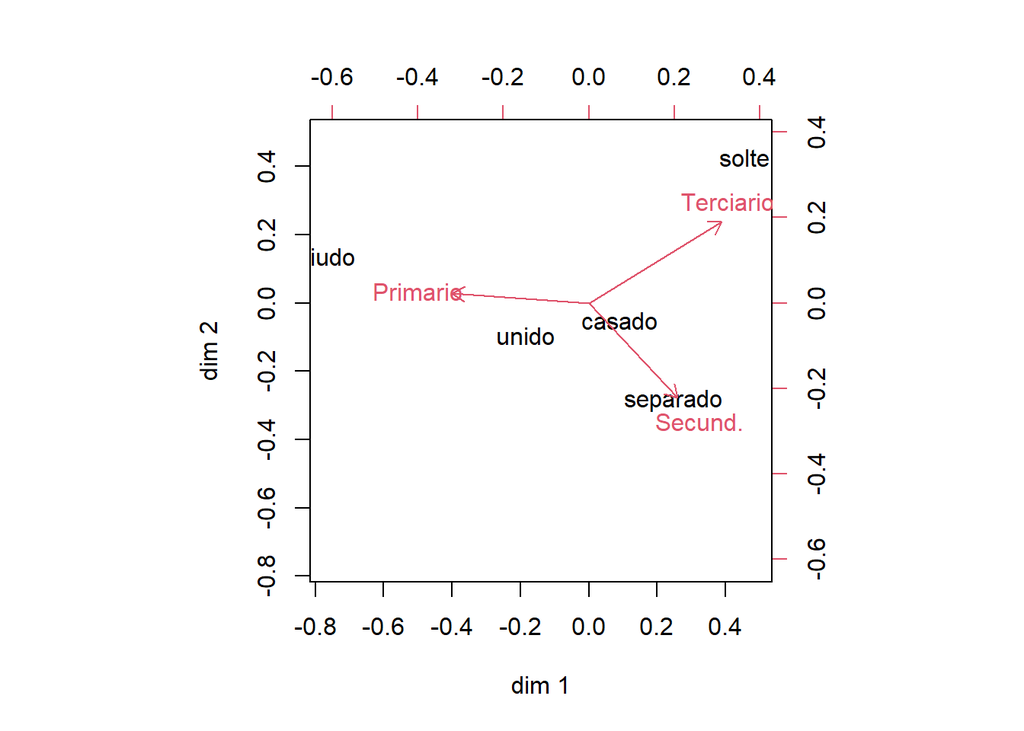

```r
biplot(Y,W,var.axes = TRUE,xlab="dim 1", ylab="dim 2")
```

```r
###Usando el paquete ca

library(ca)
mod1=ca(X);mod1
```

```
##
##  Principal inertias (eigenvalues):
##            1        2
## Value      0.131692 0.037453
## Percentage 77.86%   22.14%
##
##
##  Rows:
##             unido   casado separado     viudo   soltero
## Mass     0.113475 0.489362 0.127660  0.148936  0.120567
## ChiDist  0.206801 0.104368 0.378106  0.778244  0.647228
## Inertia  0.004853 0.005330 0.018251  0.090205  0.050506
## Dim. 1  -0.507000 0.251108 0.684876 -2.110738  1.340191
## Dim. 2   0.487886 0.262902 1.472365 -0.711241 -2.206644
##
##
##  Columns:
##          Primario  Secund. TerciarioUniv.
## Mass     0.446809 0.280142       0.273050
## ChiDist  0.401245 0.379991       0.455932
## Inertia  0.071935 0.040451       0.056760
## Dim. 1  -1.102877 0.714819       1.071321
## Dim. 2  -0.147507 1.434801      -1.230694
```

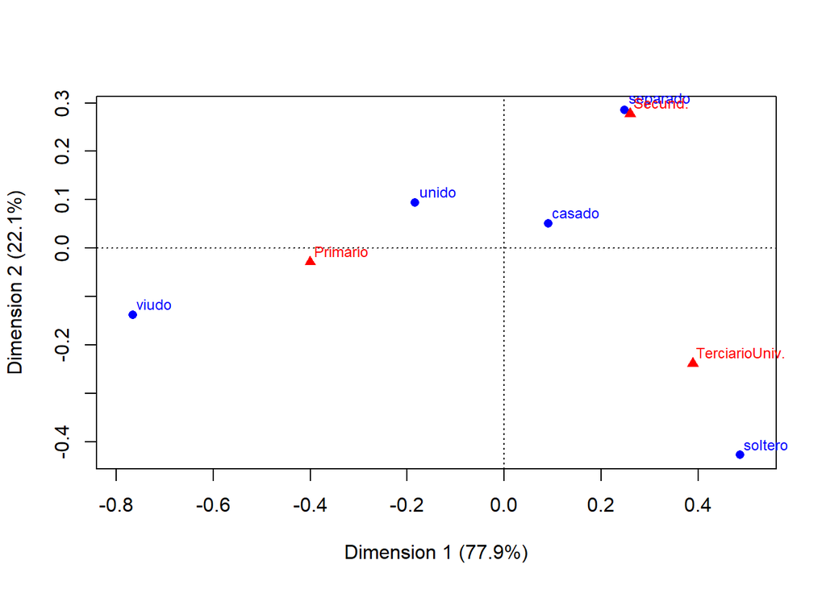

```r
plot(mod1)
```

ANALISIS DE CORRESPONDENCIA MULTIPLE

```r
#tabla con  las variables dummy
tabla=read.table("eph_dummy.dat",header=TRUE)
dim(tabla)
```

```
## [1] 282  11
```

```r
names(tabla)
```

```
##  [1] "EC1"  "EC2"  "EC3"  "EC4"  "EC5"  "NE1"  "NE2"  "NE3"  "EST1" "EST2"
## [11] "EST3"
```

```r
#Est : Estado civil("unido", "casado", "separado","viudo","soltero")
#NE: Nivel de educaci?n("Primario", "Secund.", "TerciarioUniv.")
#EST: ESTADO (ocupado, desocupado, subocupado)

#se eligen 40 observaciones
X=as.matrix(tabla[1:40,])
#definir tama?o de filas y columnas
di=dim(X);di
```

```
## [1] 40 11
```

```r
f=di[1];f
```

```
## [1] 40
```

```r
c=di[2];c
```

```
## [1] 11
```

```r
 #matriz de frecuencias relativas#
F=(1/f)*X

#frecuencias relativas marginales por fila
unos=c(rep(1,c))
sf=(c(F%*%unos))
Df=diag(sf)
di2=dim(Df)
#matriz de porcentajes fila.
PF=solve(Df)%*%F

#frecuencias relativas marginales por columna
unoss=c(rep(1,f))
sc=c(t(F)%*%unoss)
Dc=diag(sc)
PC=solve(Dc)%*%t(F)

#Matriz de datos transformados ZF (para nube de individuos)
  #(proyecci?n de filas en el espacio de las columnas)
ZF=solve(Df)%*%F%*%solve(Dc^(0.5))
dim(ZF)
```

```
## [1] 40 11
```

```r
#Matriz de datos transformados ZC (para nube de variables)
  #(proyecci?n de columnas en el espacio de las filas)
ZC=solve(Dc)%*%t(F)%*%solve(Df^(0.5))
dim(ZC)
```

```
## [1] 11 40
```

```r
#Matriz para obtener los valores y vectores propios
Zas=solve((Df^(0.5)))%*%F%*%solve((Dc^(0.5)))
dim(Zas)
```

```
## [1] 40 11
```

```r
#descomposicion singular#
ds=svd(Zas)

Zasvp=(ds$d)^2 ;Zasvp  #valores propios#
```

```
##  [1] 1.000000e+00 6.503000e-01 4.817872e-01 3.829145e-01 3.527874e-01
##  [6] 2.963022e-01 2.394221e-01 1.609253e-01 1.022279e-01 1.477405e-32
## [11] 4.551436e-33
```

```r
val.propios=Zasvp[2:c];val.propios
```

```
##  [1] 6.503000e-01 4.817872e-01 3.829145e-01 3.527874e-01 2.963022e-01
##  [6] 2.394221e-01 1.609253e-01 1.022279e-01 1.477405e-32 4.551436e-33
```

```r
l=length(val.propios);l
```

```
## [1] 10
```

```r
v.p.acumulados=c()
for (i in 1:l){v.p.acumulados[i]=sum(val.propios[1:i])}
s=sum(val.propios)
porcentaje=(1/s)*v.p.acumulados
vvac=cbind(val.propios,porcentaje)
vvac
```

```
##        val.propios porcentaje
##  [1,] 6.503000e-01  0.2438625
##  [2,] 4.817872e-01  0.4245327
##  [3,] 3.829145e-01  0.5681257
##  [4,] 3.527874e-01  0.7004209
##  [5,] 2.963022e-01  0.8115343
##  [6,] 2.394221e-01  0.9013175
##  [7,] 1.609253e-01  0.9616645
##  [8,] 1.022279e-01  1.0000000
##  [9,] 1.477405e-32  1.0000000
## [10,] 4.551436e-33  1.0000000
```

```r
ds$v[,1]
```

```
##  [1] -0.09128709 -0.40824829 -0.20412415 -0.25819889 -0.22360680 -0.40824829
##  [7] -0.30276504 -0.27386128 -0.40824829 -0.15811388 -0.37638633
```

```r
A=ds$v[,2:c]   #vectores propios filas (individuos)#
dim(A)
```

```
## [1] 11 10
```

```r
B=ds$u[,2:c]  #vectores propios columnas (variables)#
dim(B)
```

```
## [1] 40 10
```

```r
Y12=ZF%*%A[,1:2]    #2 primeras coordenada fila#

Y=ZF%*%A     #10 coordenada fila#

W12=ZC%*%B[,1:2]
rownames(W12)=colnames(tabla);W12
```

```
##             [,1]        [,2]
## EC1  -0.01754798  2.09010058
## EC2  -0.08276757  0.06845809
## EC3  -0.06424867 -0.90028566
## EC4   0.80355571  0.08022917
## EC5  -0.73905048  0.06672210
## NE1   0.48265446 -0.11072500
## NE2  -0.44275721 -0.39643845
## NE3  -0.53141776  0.73059145
## EST1 -0.41840742 -0.01495411
## EST2 -0.12742841 -1.03510908
## EST3  0.51473139  0.20025938
```

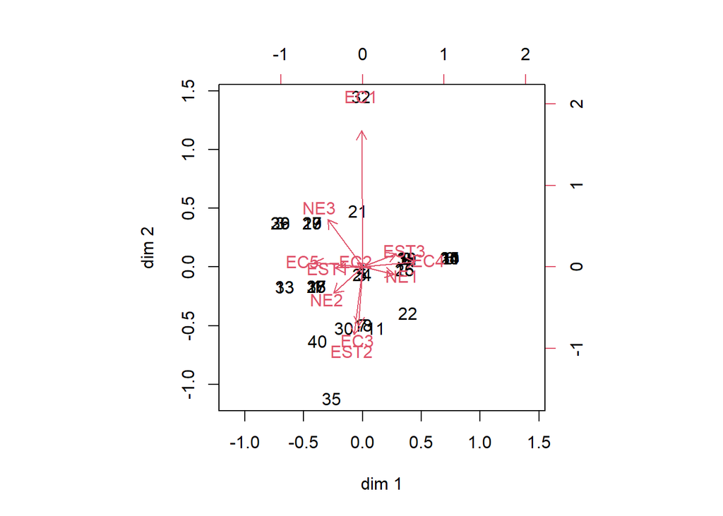

```r
W=ZC%*%B     #10 coordenadas col#
rownames(W)=colnames(tabla)

biplot(Y,W,var.axes = TRUE,xlab="dim 1", ylab="dim 2")
```

```r
#plot(W)
#identify(W[,1],W[,2])

#utilizando el  la funci?n mjca (del paquete ca)
x=read.table("eph.dat",header=TRUE)

dim(x)
```

```
## [1] 282   4
```

```r
library(ca)
mod3=mjca(x[,1:4]) ; mod3
```

```
##
##  Eigenvalues:
##            1        2        3        4
## Value      0.096748 0.021571 0.007896 0.001623
## Percentage 60.09%   13.4%    4.9%     1.01%
##
##
##  Columns:
##            SEXO:1    SEXO:2  ESTCIV:1  ESTCIV:2  ESTCIV:3  ESTCIV:4  ESTCIV:5
## Mass     0.161348  0.088652  0.028369  0.122340  0.031915  0.037234  0.030142
## ChiDist  0.452980  0.824423  1.425496  0.604246  1.372255  1.412237  1.445072
## Inertia  0.033107  0.060255  0.057647  0.044668  0.060098  0.074260  0.062943
## Dim. 1   0.770929 -1.403091  0.102019  0.925002 -0.143596 -2.552992 -0.544700
## Dim. 2  -0.643700  1.171534 -0.643468 -0.821340  2.089803 -0.915543  2.857525
##         NIVEL_ED:1 NIVEL_ED:2 NIVEL_ED:3 ESTADO:1  ESTADO:2  ESTADO:3
## Mass      0.111702   0.070035   0.068262 0.155142  0.012411  0.082447
## ChiDist   0.620858   0.842504   0.859485 0.442952  2.244938  0.810038
## Inertia   0.043057   0.049712   0.050426 0.030440  0.062550  0.054098
## Dim. 1   -0.841661   0.857475   0.497517 0.724686 -0.345435 -1.311656
## Dim. 2   -0.997794   0.400304   1.222052 0.418093 -0.114281 -0.769531
```

```r
plot.mjca(mod3)
Coord=cacoord(mod3) ####extrae las coordenadas
Coord$row[1:5,]  # coordenadas columnas
```

```
##         Dim1      Dim2       Dim3        Dim4
## 1  2.6347532 -1.100703  0.7034324 -10.6536567
## 2 -0.3676218 -5.502063 -3.2749704  -0.3463936
## 3  1.1641720  6.560146 -8.1326028  20.2914635
## 4  1.2690798 -3.480515 -1.6954994  -0.8718451
## 5  0.9980517 -3.122251 -0.8760386 -10.1282052
```

```r
Coord$col #coordenadas filas
```

```
##          Dim1       Dim2        Dim3       Dim4
## 1   0.7709293 -0.6437002 -0.09933253  0.1572955
## 2  -1.4030913  1.1715343  0.18078521 -0.2862777
## 3   0.1020188 -0.6434680  2.63594188  2.7495728
## 4   0.9250022 -0.8213404 -0.63814909 -0.2586228
## 5  -0.1435960  2.0898032  1.97600640 -2.5637157
## 6  -2.5529916 -0.9155430 -0.54066296 -0.7991512
## 7  -0.5446999  2.8575246 -1.31511623  2.1635801
## 8  -0.8416613 -0.9977939  0.20101926  0.1717097
## 9   0.8574745  0.4003039  1.05368796 -1.4047696
## 10  0.4975173  1.2220522 -1.40999709  1.1602777
## 11  0.7246862  0.4180931 -0.06618056 -0.2108927
## 12 -0.3454353 -0.1142814  4.99619909  3.4745452
## 13 -1.3116558 -0.7695307 -0.62758268 -0.1262087
```

```r
names(mod3)
```

```
##  [1] "sv"         "lambda"     "inertia.e"  "inertia.t"  "inertia.et"
##  [6] "levelnames" "factors"    "levels.n"   "nd"         "nd.max"
## [11] "rownames"   "rowmass"    "rowdist"    "rowinertia" "rowcoord"
## [16] "rowpcoord"  "rowctr"     "rowcor"     "colnames"   "colmass"
## [21] "coldist"    "colinertia" "colcoord"   "colpcoord"  "colctr"
## [26] "colcor"     "colsup"     "subsetcol"  "Burt"       "Burt.upd"
## [31] "subinertia" "JCA.iter"   "indmat"     "call"
```

```r
mod3$colnames
```

```
## [1] "SEXO"     "ESTCIV"   "NIVEL_ED" "ESTADO"
```

```r
rownames(W)=colnames(tabla)
mod3$Burt
```

```
##            SEXO:1 SEXO:2 ESTCIV:1 ESTCIV:2 ESTCIV:3 ESTCIV:4 ESTCIV:5
## SEXO:1        182      0       23      129       12        9        9
## SEXO:2          0    100        9        9       24       33       25
## ESTCIV:1       23      9       32        0        0        0        0
## ESTCIV:2      129      9        0      138        0        0        0
## ESTCIV:3       12     24        0        0       36        0        0
## ESTCIV:4        9     33        0        0        0       42        0
## ESTCIV:5        9     25        0        0        0        0       34
## NIVEL_ED:1     75     51       17       55       11       35        8
## NIVEL_ED:2     56     23        9       44       16        3        7
## NIVEL_ED:3     51     26        6       39        9        4       19
## ESTADO:1      127     48       19       98       27        9       22
## ESTADO:2        9      5        5        3        3        1        2
## ESTADO:3       46     47        8       37        6       32       10
##            NIVEL_ED:1 NIVEL_ED:2 NIVEL_ED:3 ESTADO:1 ESTADO:2 ESTADO:3
## SEXO:1             75         56         51      127        9       46
## SEXO:2             51         23         26       48        5       47
## ESTCIV:1           17          9          6       19        5        8
## ESTCIV:2           55         44         39       98        3       37
## ESTCIV:3           11         16          9       27        3        6
## ESTCIV:4           35          3          4        9        1       32
## ESTCIV:5            8          7         19       22        2       10
## NIVEL_ED:1        126          0          0       56        9       61
## NIVEL_ED:2          0         79          0       61        4       14
## NIVEL_ED:3          0          0         77       58        1       18
## ESTADO:1           56         61         58      175        0        0
## ESTADO:2            9          4          1        0       14        0
## ESTADO:3           61         14         18        0        0       93
```

```r
mod3$levelnames
```

```
##  [1] "SEXO:1"     "SEXO:2"     "ESTCIV:1"   "ESTCIV:2"   "ESTCIV:3"
##  [6] "ESTCIV:4"   "ESTCIV:5"   "NIVEL_ED:1" "NIVEL_ED:2" "NIVEL_ED:3"
## [11] "ESTADO:1"   "ESTADO:2"   "ESTADO:3"
```

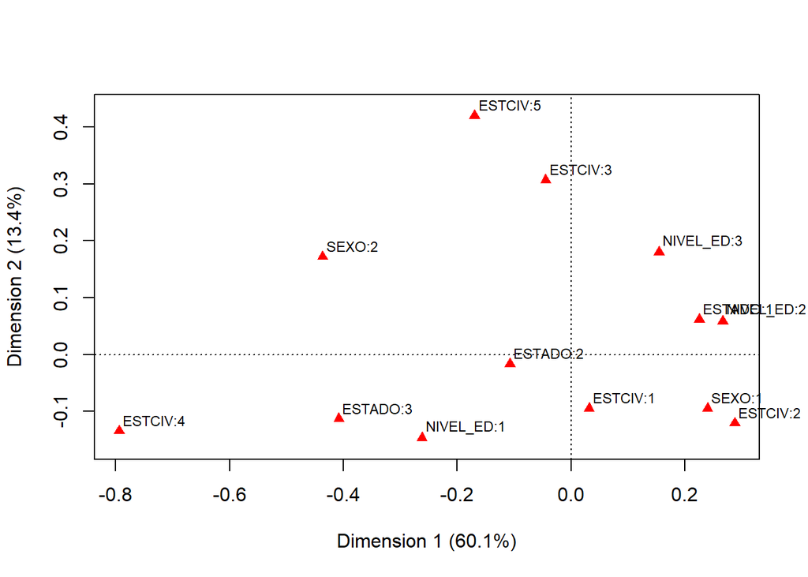

```r
plot(mod3)
```

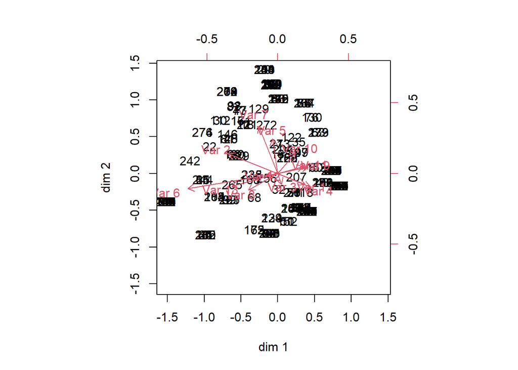

```r
biplot(mod3$rowpcoord,mod3$colpcoord,var.axes = TRUE,xlab="dim 1", ylab="dim 2")
```

ANALISIS FACTORIAL EXPLORATORIO

Ejemplo

Estos datos corresponden a 51 observaciones y 9 variables. Las observaciones son las provincias españolas más Ceuta y Melilla, que aparecen unidas como una única provincia, y las variables los nueve epígrafes en los que se desglosa la Encuesta de Presupuestos Familiares en Espa?a. Las variables son:

G.1 alimentación  
G.2 vestido y calzado  
G.3 vivienda  
G.4 mobiliario dom?stico  
G.5 gastos sanitarios  
G.6 transporte  
G.7 enseñanza y cultura  
G.8 turismo y ocio  
G.9 otros gastos

Base: epf.dat.Fuente: Encuesta de Presupuestos Familiares del a?o 1990/91

```r
Datos=read.table("epf.dat",header=TRUE)
Datos=Datos[,2:10]
#
library(psych)### para trabajar con modelos m?s complejos de analisis factorial
dim(Datos)
```

```
## [1] 51  9
```

```r
Descriptivo=describe(Datos) # del paquete psych (resultados como tabla)

#Describe la estructura de correlacion de los datos.
    #Si un grupo de variables est?n altamente correlacionadas entre ellas pero a su vez no están tan correlacionadas con otro grupo esto permite sospechar que existe un factor no observado que causa este comportamiento diferenciado"
lowerCor(Datos)
```

```
##     G.1  G.2  G.3  G.4  G.5  G.6  G.7  G.8  G.9
## G.1 1.00
## G.2 0.53 1.00
## G.3 0.48 0.55 1.00
## G.4 0.52 0.63 0.70 1.00
## G.5 0.47 0.51 0.67 0.67 1.00
## G.6 0.53 0.59 0.69 0.73 0.73 1.00
## G.7 0.59 0.55 0.83 0.76 0.81 0.74 1.00
## G.8 0.44 0.46 0.81 0.76 0.71 0.73 0.84 1.00
## G.9 0.48 0.53 0.54 0.64 0.59 0.71 0.56 0.58 1.00
```

```r
#pairs.panels(Datos,show.points=FALSE)
 #para observar la estructura de correlaci?n diferenciada por colores según el grado de la correlación
#cor.plot(Datos, numbers = TRUE)
```

```r
# ##una forma de ver el número  de factores
Nfac=principal(Datos, nfactors = 6, covar = FALSE) #funci?n del paquete pysch
Nfac
```

```
## Principal Components Analysis
## Call: principal(r = Datos, nfactors = 6, covar = FALSE)
## Standardized loadings (pattern matrix) based upon correlation matrix
##      RC1  RC3  RC5  RC4  RC2  RC6   h2     u2 com
## G.1 0.20 0.20 0.16 0.21 0.91 0.12 1.00 0.0028 1.4
## G.2 0.22 0.23 0.17 0.88 0.23 0.17 0.99 0.0096 1.6
## G.3 0.87 0.22 0.20 0.27 0.17 0.09 0.95 0.0505 1.6
## G.4 0.43 0.30 0.26 0.31 0.20 0.71 0.98 0.0196 3.1
## G.5 0.39 0.26 0.81 0.18 0.17 0.17 0.97 0.0279 2.0
## G.6 0.43 0.55 0.43 0.26 0.20 0.22 0.83 0.1707 4.0
## G.7 0.69 0.18 0.48 0.18 0.31 0.24 0.93 0.0709 2.9
## G.8 0.77 0.29 0.28 0.07 0.13 0.36 0.91 0.0888 2.2
## G.9 0.24 0.88 0.18 0.20 0.19 0.16 0.96 0.0369 1.5
##
##                        RC1  RC3  RC5  RC4  RC2  RC6
## SS loadings           2.49 1.49 1.35 1.17 1.17 0.85
## Proportion Var        0.28 0.17 0.15 0.13 0.13 0.09
## Cumulative Var        0.28 0.44 0.59 0.72 0.85 0.95
## Proportion Explained  0.29 0.18 0.16 0.14 0.14 0.10
## Cumulative Proportion 0.29 0.47 0.63 0.76 0.90 1.00
##
## Mean item complexity =  2.3
## Test of the hypothesis that 6 components are sufficient.
##
## The root mean square of the residuals (RMSR) is  0.02
##  with the empirical chi square  1.9  with prob <  NA
##
## Fit based upon off diagonal values = 1
```

```r
Nfac$loadings
```

```
##
## Loadings:
##     RC1   RC3   RC5   RC4   RC2   RC6
## G.1 0.205 0.198 0.156 0.212 0.913 0.118
## G.2 0.220 0.227 0.165 0.884 0.228 0.172
## G.3 0.866 0.220 0.202 0.273 0.167
## G.4 0.426 0.304 0.256 0.309 0.198 0.711
## G.5 0.389 0.265 0.813 0.178 0.168 0.173
## G.6 0.429 0.553 0.435 0.255 0.197 0.217
## G.7 0.692 0.178 0.482 0.176 0.312 0.243
## G.8 0.771 0.288 0.284       0.125 0.363
## G.9 0.238 0.878 0.184 0.197 0.191 0.163
##
##                  RC1   RC3   RC5   RC4   RC2   RC6
## SS loadings    2.487 1.492 1.354 1.169 1.168 0.852
## Proportion Var 0.276 0.166 0.150 0.130 0.130 0.095
## Cumulative Var 0.276 0.442 0.593 0.723 0.852 0.947
```

```r
Nfac$values
```

```
## [1] 6.08732572 0.77720888 0.55666880 0.47914455 0.34768511 0.27435674 0.22712456
## [8] 0.15329446 0.09719117
```

```r
princomp(Datos,cor=TRUE)
```

```
## Call:
## princomp(x = Datos, cor = TRUE)
##
## Standard deviations:
##    Comp.1    Comp.2    Comp.3    Comp.4    Comp.5    Comp.6    Comp.7    Comp.8
## 2.4672506 0.8815945 0.7461024 0.6922027 0.5896483 0.5237907 0.4765759 0.3915284
##    Comp.9
## 0.3117550
##
##  9  variables and  51 observations.
```

```r
## ?Cuántas componentes elegiría?
## determine el nro de factores utilizando la la desigualdad (p-m)2 >= p + m

#factanal (paquete stats) estima por máxima verosimilitud
.FA <- factanal(Datos,factors=3, rotation="none", scores="Bartlett", data=Datos);.FA
```

```
##
## Call:
## factanal(x = Datos, factors = 3, data = Datos, scores = "Bartlett",     rotation = "none")
##
## Uniquenesses:
##   G.1   G.2   G.3   G.4   G.5   G.6   G.7   G.8   G.9
## 0.550 0.473 0.258 0.273 0.299 0.227 0.005 0.005 0.341
##
## Loadings:
##     Factor1 Factor2 Factor3
## G.1  0.540   0.287   0.277
## G.2  0.533   0.466   0.158
## G.3  0.858
## G.4  0.792   0.316
## G.5  0.794   0.182   0.193
## G.6  0.773   0.418
## G.7  0.960           0.271
## G.8  0.958          -0.277
## G.9  0.604   0.542
##
##                Factor1 Factor2 Factor3
## SS loadings      5.371   0.905   0.293
## Proportion Var   0.597   0.101   0.033
## Cumulative Var   0.597   0.697   0.730
##
## Test of the hypothesis that 3 factors are sufficient.
## The chi square statistic is 7.27 on 12 degrees of freedom.
## The p-value is 0.839
```

```r
.FA
```

```
##
## Call:
## factanal(x = Datos, factors = 3, data = Datos, scores = "Bartlett",     rotation = "none")
##
## Uniquenesses:
##   G.1   G.2   G.3   G.4   G.5   G.6   G.7   G.8   G.9
## 0.550 0.473 0.258 0.273 0.299 0.227 0.005 0.005 0.341
##
## Loadings:
##     Factor1 Factor2 Factor3
## G.1  0.540   0.287   0.277
## G.2  0.533   0.466   0.158
## G.3  0.858
## G.4  0.792   0.316
## G.5  0.794   0.182   0.193
## G.6  0.773   0.418
## G.7  0.960           0.271
## G.8  0.958          -0.277
## G.9  0.604   0.542
##
##                Factor1 Factor2 Factor3
## SS loadings      5.371   0.905   0.293
## Proportion Var   0.597   0.101   0.033
## Cumulative Var   0.597   0.697   0.730
##
## Test of the hypothesis that 3 factors are sufficient.
## The chi square statistic is 7.27 on 12 degrees of freedom.
## The p-value is 0.839
```

```r
names(.FA)
```

```
##  [1] "converged"    "loadings"     "uniquenesses" "correlation"  "criteria"
##  [6] "factors"      "dof"          "method"       "scores"       "STATISTIC"
## [11] "PVAL"         "n.obs"        "call"
```

```r
.FA$converged
```

```
## [1] TRUE
```

```r
 unclass(.FA$loadings)###muestra todas las carga
```

```
##       Factor1      Factor2      Factor3
## G.1 0.5395012  0.286940606  0.276955567
## G.2 0.5329312  0.466318220  0.158282062
## G.3 0.8576967  0.068068721  0.040221790
## G.4 0.7921123  0.315566133  0.001707309
## G.5 0.7941632  0.182324308  0.192896546
## G.6 0.7728202  0.417606764  0.036630154
## G.7 0.9599701 -0.016802886  0.270529938
## G.8 0.9581863 -0.008285967 -0.277149486
## G.9 0.6039528  0.541647185 -0.030343186
```

```r
#fa (paquete psych) se puede elegir el metodo de estimaci?n 'pa' para ejes principales, 'ml' para m?xima verosmilitud
.FA <- fa(Datos,nfactors=2, rotate="none",fm="pa");.FA
```

```
## Factor Analysis using method =  pa
## Call: fa(r = Datos, nfactors = 2, rotate = "none", fm = "pa")
## Standardized loadings (pattern matrix) based upon correlation matrix
##      PA1   PA2   h2   u2 com
## G.1 0.62  0.23 0.43 0.57 1.3
## G.2 0.68  0.34 0.57 0.43 1.5
## G.3 0.84 -0.19 0.75 0.25 1.1
## G.4 0.85  0.07 0.73 0.27 1.0
## G.5 0.82 -0.07 0.67 0.33 1.0
## G.6 0.86  0.11 0.75 0.25 1.0
## G.7 0.92 -0.22 0.90 0.10 1.1
## G.8 0.87 -0.31 0.85 0.15 1.2
## G.9 0.72  0.23 0.57 0.43 1.2
##
##                        PA1  PA2
## SS loadings           5.81 0.42
## Proportion Var        0.65 0.05
## Cumulative Var        0.65 0.69
## Proportion Explained  0.93 0.07
## Cumulative Proportion 0.93 1.00
##
## Mean item complexity =  1.2
## Test of the hypothesis that 2 factors are sufficient.
##
## The degrees of freedom for the null model are  36  and the objective function was  7.81 with Chi Square of  360.37
## The degrees of freedom for the model are 19  and the objective function was  0.47
##
## The root mean square of the residuals (RMSR) is  0.03
## The df corrected root mean square of the residuals is  0.04
##
## The harmonic number of observations is  51 with the empirical chi square  3.33  with prob <  1
## The total number of observations was  51  with Likelihood Chi Square =  21.03  with prob <  0.33
##
## Tucker Lewis Index of factoring reliability =  0.988
## RMSEA index =  0.041  and the 90 % confidence intervals are  0 0.136
## BIC =  -53.67
## Fit based upon off diagonal values = 1
## Measures of factor score adequacy
##                                                    PA1  PA2
## Correlation of (regression) scores with factors   0.98 0.78
## Multiple R square of scores with factors          0.96 0.61
## Minimum correlation of possible factor scores     0.92 0.22
```

```r
.FA$uniquenesses
```

```
##       G.1       G.2       G.3       G.4       G.5       G.6       G.7       G.8
## 0.5690670 0.4292171 0.2535531 0.2695798 0.3295833 0.2460861 0.1044884 0.1476806
##       G.9
## 0.4261560
```

```r
.FA$weights
```

```
##            PA1         PA2
## G.1 0.03372916  0.23968096
## G.2 0.10353321  0.34266438
## G.3 0.07313372 -0.07757296
## G.4 0.12958933  0.28499204
## G.5 0.04687845  0.03461606
## G.6 0.17343078  0.30818469
## G.7 0.33815163 -0.51492213
## G.8 0.14565137 -0.67617332
## G.9 0.10202059  0.23591985
```

```r
.FA <- fa(Datos,nfactors=2, rotate="none",fm="lm");.FA
```

```
## factor method not specified correctly, minimum residual (unweighted least squares  used
```

```
## Factor Analysis using method =  minres
## Call: fa(r = Datos, nfactors = 2, rotate = "none", fm = "lm")
## Standardized loadings (pattern matrix) based upon correlation matrix
##      MR1   MR2   h2   u2 com
## G.1 0.62  0.23 0.43 0.57 1.3
## G.2 0.68  0.34 0.57 0.43 1.5
## G.3 0.84 -0.19 0.75 0.25 1.1
## G.4 0.85  0.07 0.73 0.27 1.0
## G.5 0.82 -0.07 0.67 0.33 1.0
## G.6 0.86  0.11 0.75 0.25 1.0
## G.7 0.92 -0.21 0.89 0.11 1.1
## G.8 0.87 -0.31 0.86 0.14 1.3
## G.9 0.72  0.23 0.57 0.43 1.2
##
##                        MR1  MR2
## SS loadings           5.81 0.42
## Proportion Var        0.65 0.05
## Cumulative Var        0.65 0.69
## Proportion Explained  0.93 0.07
## Cumulative Proportion 0.93 1.00
##
## Mean item complexity =  1.2
## Test of the hypothesis that 2 factors are sufficient.
##
## The degrees of freedom for the null model are  36  and the objective function was  7.81 with Chi Square of  360.37
## The degrees of freedom for the model are 19  and the objective function was  0.47
##
## The root mean square of the residuals (RMSR) is  0.03
## The df corrected root mean square of the residuals is  0.04
##
## The harmonic number of observations is  51 with the empirical chi square  3.33  with prob <  1
## The total number of observations was  51  with Likelihood Chi Square =  21.1  with prob <  0.33
##
## Tucker Lewis Index of factoring reliability =  0.987
## RMSEA index =  0.042  and the 90 % confidence intervals are  0 0.136
## BIC =  -53.6
## Fit based upon off diagonal values = 1
## Measures of factor score adequacy
##                                                    MR1  MR2
## Correlation of (regression) scores with factors   0.98 0.78
## Multiple R square of scores with factors          0.96 0.61
## Minimum correlation of possible factor scores     0.92 0.22
```

```r
.FA$uniquenesses
```

```
##       G.1       G.2       G.3       G.4       G.5       G.6       G.7       G.8
## 0.5685870 0.4260974 0.2543843 0.2696456 0.3296195 0.2466087 0.1059961 0.1448961
##       G.9
## 0.4278981
```

```r
.FA$weights
```

```
##            MR1         MR2
## G.1 0.03437713  0.23708326
## G.2 0.10510763  0.34849414
## G.3 0.07203374 -0.07385465
## G.4 0.12880433  0.28489045
## G.5 0.04777239  0.03159372
## G.6 0.17294004  0.30547422
## G.7 0.33472944 -0.49765070
## G.8 0.14996488 -0.69207889
## G.9 0.10089487  0.23253613
```

```r
#analice los resultados de los cargas factoriales y las varianzas residuales segun los metodos.

#determinar el nro de factores
 #para determinar el nro de factores
library(nFactors)
eig=eigen(cor(Datos))
nBartlett(eig$values, N=51)#indica el nro de factores con tres prue as (bartlett,anderson  y lawley )
```

```
## bartlett anderson   lawley
##        4        5        6
```

```r
# https://www.rdocumentation.org/packages/nFactors/versions/2.3.1/topics/nBartlett

#- Estimando por máxima verosimilitud determine el número de factores comparando el resultado de la prueba estadística y algun criterio de selección.



# definida la cantidad de factores determinar los resultados con las rotaciones
library(GPArotation)
#"varimax":maximiza la suma de varianzas de las cargas factoriales al cuadrado dentro de cada factor (opera en las columnas de la matriz de carga)
#"quartimax" maximiza la dispersión de las cargas dentro  de los variables  entre los factores. Opera en filas de la matriz de cargas

#- determinado el modelo encuentre los factores.
#- grafique las ciudades segun los factores determinados


.FA <- fa(Datos,nfactors=3, rotate="none",fm="lm");.FA
```

```
## factor method not specified correctly, minimum residual (unweighted least squares  used
```

```
## Factor Analysis using method =  minres
## Call: fa(r = Datos, nfactors = 3, rotate = "none", fm = "lm")
## Standardized loadings (pattern matrix) based upon correlation matrix
##      MR1   MR2   MR3   h2    u2 com
## G.1 0.62  0.23  0.23 0.49 0.509 1.6
## G.2 0.68  0.33  0.16 0.60 0.405 1.6
## G.3 0.84 -0.19  0.05 0.74 0.257 1.1
## G.4 0.85  0.06 -0.02 0.72 0.276 1.0
## G.5 0.81 -0.07 -0.03 0.67 0.332 1.0
## G.6 0.87  0.12 -0.18 0.79 0.207 1.1
## G.7 0.93 -0.26  0.21 0.98 0.019 1.3
## G.8 0.87 -0.30 -0.14 0.87 0.134 1.3
## G.9 0.73  0.28 -0.23 0.66 0.335 1.5
##
##                        MR1  MR2  MR3
## SS loadings           5.84 0.46 0.23
## Proportion Var        0.65 0.05 0.03
## Cumulative Var        0.65 0.70 0.73
## Proportion Explained  0.89 0.07 0.03
## Cumulative Proportion 0.89 0.97 1.00
##
## Mean item complexity =  1.3
## Test of the hypothesis that 3 factors are sufficient.
##
## The degrees of freedom for the null model are  36  and the objective function was  7.81 with Chi Square of  360.37
## The degrees of freedom for the model are 12  and the objective function was  0.28
##
## The root mean square of the residuals (RMSR) is  0.02
## The df corrected root mean square of the residuals is  0.03
##
## The harmonic number of observations is  51 with the empirical chi square  1.39  with prob <  1
## The total number of observations was  51  with Likelihood Chi Square =  12.4  with prob <  0.41
##
## Tucker Lewis Index of factoring reliability =  0.996
## RMSEA index =  0.016  and the 90 % confidence intervals are  0 0.148
## BIC =  -34.78
## Fit based upon off diagonal values = 1
## Measures of factor score adequacy
##                                                    MR1  MR2  MR3
## Correlation of (regression) scores with factors   0.99 0.83 0.78
## Multiple R square of scores with factors          0.97 0.69 0.61
## Minimum correlation of possible factor scores     0.95 0.39 0.22
```

```r
.FA <- fa(Datos,nfactors=3, rotate="varimax",fm="lm");.FA
```

```
## factor method not specified correctly, minimum residual (unweighted least squares  used
```

```
## Factor Analysis using method =  minres
## Call: fa(r = Datos, nfactors = 3, rotate = "varimax", fm = "lm")
## Standardized loadings (pattern matrix) based upon correlation matrix
##      MR1  MR2  MR3   h2    u2 com
## G.1 0.29 0.60 0.22 0.49 0.509 1.7
## G.2 0.25 0.65 0.33 0.60 0.405 1.8
## G.3 0.73 0.36 0.29 0.74 0.257 1.8
## G.4 0.55 0.46 0.45 0.72 0.276 2.9
## G.5 0.62 0.36 0.39 0.67 0.332 2.4
## G.6 0.51 0.41 0.61 0.79 0.207 2.7
## G.7 0.86 0.46 0.19 0.98 0.019 1.6
## G.8 0.82 0.19 0.41 0.87 0.134 1.6
## G.9 0.30 0.39 0.65 0.66 0.335 2.1
##
##                        MR1  MR2  MR3
## SS loadings           3.13 1.81 1.59
## Proportion Var        0.35 0.20 0.18
## Cumulative Var        0.35 0.55 0.73
## Proportion Explained  0.48 0.28 0.24
## Cumulative Proportion 0.48 0.76 1.00
##
## Mean item complexity =  2.1
## Test of the hypothesis that 3 factors are sufficient.
##
## The degrees of freedom for the null model are  36  and the objective function was  7.81 with Chi Square of  360.37
## The degrees of freedom for the model are 12  and the objective function was  0.28
##
## The root mean square of the residuals (RMSR) is  0.02
## The df corrected root mean square of the residuals is  0.03
##
## The harmonic number of observations is  51 with the empirical chi square  1.39  with prob <  1
## The total number of observations was  51  with Likelihood Chi Square =  12.4  with prob <  0.41
##
## Tucker Lewis Index of factoring reliability =  0.996
## RMSEA index =  0.016  and the 90 % confidence intervals are  0 0.148
## BIC =  -34.78
## Fit based upon off diagonal values = 1
## Measures of factor score adequacy
##                                                    MR1  MR2  MR3
## Correlation of (regression) scores with factors   0.95 0.80 0.86
## Multiple R square of scores with factors          0.90 0.64 0.73
## Minimum correlation of possible factor scores     0.81 0.28 0.46
```

```r
.FA <- fa(Datos,nfactors=3, rotate="quartimax",fm="lm");.FA
```

```
## factor method not specified correctly, minimum residual (unweighted least squares  used
```

```
## Factor Analysis using method =  minres
## Call: fa(r = Datos, nfactors = 3, rotate = "quartimax", fm = "lm")
## Standardized loadings (pattern matrix) based upon correlation matrix
##      MR1   MR2   MR3   h2    u2 com
## G.1 0.60  0.36 -0.01 0.49 0.509 1.6
## G.2 0.65  0.41  0.11 0.60 0.405 1.7
## G.3 0.85 -0.06 -0.12 0.74 0.257 1.0
## G.4 0.84  0.09  0.09 0.72 0.276 1.0
## G.5 0.82 -0.02  0.01 0.67 0.332 1.0
## G.6 0.85  0.04  0.25 0.79 0.207 1.2
## G.7 0.95 -0.02 -0.29 0.98 0.019 1.2
## G.8 0.89 -0.26 -0.05 0.87 0.134 1.2
## G.9 0.71  0.12  0.38 0.66 0.335 1.6
##
##                        MR1  MR2  MR3
## SS loadings           5.81 0.39 0.33
## Proportion Var        0.65 0.04 0.04
## Cumulative Var        0.65 0.69 0.73
## Proportion Explained  0.89 0.06 0.05
## Cumulative Proportion 0.89 0.95 1.00
##
## Mean item complexity =  1.3
## Test of the hypothesis that 3 factors are sufficient.
##
## The degrees of freedom for the null model are  36  and the objective function was  7.81 with Chi Square of  360.37
## The degrees of freedom for the model are 12  and the objective function was  0.28
##
## The root mean square of the residuals (RMSR) is  0.02
## The df corrected root mean square of the residuals is  0.03
##
## The harmonic number of observations is  51 with the empirical chi square  1.39  with prob <  1
## The total number of observations was  51  with Likelihood Chi Square =  12.4  with prob <  0.41
##
## Tucker Lewis Index of factoring reliability =  0.996
## RMSEA index =  0.016  and the 90 % confidence intervals are  0 0.148
## BIC =  -34.78
## Fit based upon off diagonal values = 1
## Measures of factor score adequacy
##                                                    MR1  MR2  MR3
## Correlation of (regression) scores with factors   0.99 0.74 0.86
## Multiple R square of scores with factors          0.98 0.55 0.75
## Minimum correlation of possible factor scores     0.96 0.10 0.49
```

```r
.FA$uniquenesses
```

```
##        G.1        G.2        G.3        G.4        G.5        G.6        G.7
## 0.50878701 0.40455569 0.25695768 0.27552493 0.33236839 0.20650175 0.01928124
##        G.8        G.9
## 0.13354120 0.33545375
```

```r
.FA$weights
```

```
##               MR1         MR2         MR3
## G.1 -0.0006902603  0.31059362  0.09461850
## G.2  0.0791895659  0.42474758 -0.00921254
## G.3  0.0355080900 -0.01030237  0.05282459
## G.4  0.0855823317  0.19862240  0.18508145
## G.5 -0.0008762109 -0.11054394  0.33285334
## G.6  0.1559857867 -0.02222996  0.54450087
## G.7  0.4878628370  0.24666029 -1.62867352
## G.8  0.1738474079 -0.90659759  0.26144802
## G.9  0.1076656504  0.09221098  0.37526302
```

```r
.FA <- fa(Datos,nfactors=4, rotate="none",fm="pa");.FA
```

```
## maximum iteration exceeded
```

```
## Factor Analysis using method =  pa
## Call: fa(r = Datos, nfactors = 4, rotate = "none", fm = "pa")
## Standardized loadings (pattern matrix) based upon correlation matrix
##      PA1   PA2   PA3   PA4   h2     u2 com
## G.1 0.61  0.19  0.15 -0.06 0.44  0.564 1.3
## G.2 0.69  0.47  0.20  0.21 0.78  0.215 2.2
## G.3 0.84 -0.14  0.00  0.14 0.74  0.263 1.1
## G.4 0.85  0.08 -0.06  0.08 0.73  0.269 1.0
## G.5 0.81 -0.07 -0.02 -0.13 0.68  0.322 1.1
## G.6 0.86  0.11 -0.17 -0.16 0.81  0.187 1.2
## G.7 0.96 -0.36  0.35 -0.12 1.19 -0.193 1.6
## G.8 0.88 -0.30 -0.24  0.21 0.97  0.029 1.5
## G.9 0.73  0.24 -0.20 -0.17 0.65  0.347 1.5
##
##                        PA1  PA2  PA3  PA4
## SS loadings           5.90 0.57 0.32 0.21
## Proportion Var        0.66 0.06 0.04 0.02
## Cumulative Var        0.66 0.72 0.75 0.78
## Proportion Explained  0.84 0.08 0.05 0.03
## Cumulative Proportion 0.84 0.92 0.97 1.00
##
## Mean item complexity =  1.4
## Test of the hypothesis that 4 factors are sufficient.
##
## The degrees of freedom for the null model are  36  and the objective function was  7.81 with Chi Square of  360.37
## The degrees of freedom for the model are 6  and the objective function was  0.02
##
## The root mean square of the residuals (RMSR) is  0.01
## The df corrected root mean square of the residuals is  0.01
##
## The harmonic number of observations is  51 with the empirical chi square  0.13  with prob <  1
## The total number of observations was  51  with Likelihood Chi Square =  0.94  with prob <  0.99
##
## Tucker Lewis Index of factoring reliability =  1.1
## RMSEA index =  0  and the 90 % confidence intervals are  0 0
## BIC =  -22.65
## Fit based upon off diagonal values = 1
```

```r
.FA$uniquenesses
```

```
##         G.1         G.2         G.3         G.4         G.5         G.6
##  0.56362995  0.21506831  0.26259775  0.26862019  0.32160450  0.18652849
##         G.7         G.8         G.9
## -0.19289019  0.02860917  0.34666147
```

```r
.FA$weights
```

```
##             PA1        PA2         PA3         PA4
## G.1 -0.03223851  0.3050985 -0.29718571  0.13578734
## G.2  0.16534609  0.5652675  0.38276253  0.52950808
## G.3 -0.07216268  0.3331077 -0.46651214  0.40373358
## G.4  0.05253774  0.2966860 -0.15985064  0.09523796
## G.5 -0.07532647  0.3808672 -0.73356349  0.09593536
## G.6  0.16146414  0.2955473 -0.40138831 -0.53691253
## G.7  0.66107169 -1.6432380  3.01626675 -1.41024562
## G.8  0.13402019 -0.3553215 -1.53892072  1.26880836
## G.9  0.13788720  0.1175009  0.01503294 -0.42154143
```

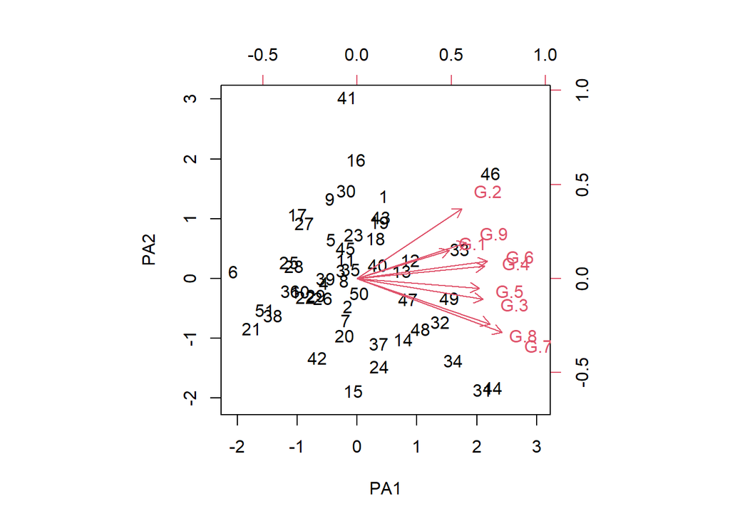

```r
# .FA$scores     # c?lculo de los factores

biplot(.FA$scores,unclass(.FA$loadings))
```

```r
# Datos$F1 <- .FA$scores[,1] # para agregar los factores
 .FA_R1<-factanal(Datos,factors=2,rotation="varimax",scores="Bartlett",data=Datos)
.FA_R1
```

```
##
## Call:
## factanal(x = Datos, factors = 2, data = Datos, scores = "Bartlett",     rotation = "varimax")
##
## Uniquenesses:
##   G.1   G.2   G.3   G.4   G.5   G.6   G.7   G.8   G.9
## 0.614 0.529 0.269 0.282 0.299 0.218 0.026 0.239 0.324
##
## Loadings:
##     Factor1 Factor2
## G.1 0.460   0.417
## G.2 0.357   0.586
## G.3 0.738   0.432
## G.4 0.575   0.622
## G.5 0.687   0.479
## G.6 0.525   0.712
## G.7 0.914   0.373
## G.8 0.738   0.466
## G.9 0.304   0.764
##
##                Factor1 Factor2
## SS loadings      3.435   2.766
## Proportion Var   0.382   0.307
## Cumulative Var   0.382   0.689
##
## Test of the hypothesis that 2 factors are sufficient.
## The chi square statistic is 18.14 on 19 degrees of freedom.
## The p-value is 0.513
```

```r
#biplot(.FA_R1$scores,unclass(.FA$loadings))

# Datos$F1 <- .FA$scores[,1] # para agregar los factores
 .FA_R1<-factanal(Datos,factors=1,rotation="none",scores="Bartlett",data=Datos)
.FA_R1
```

```
##
## Call:
## factanal(x = Datos, factors = 1, data = Datos, scores = "Bartlett",     rotation = "none")
##
## Uniquenesses:
##   G.1   G.2   G.3   G.4   G.5   G.6   G.7   G.8   G.9
## 0.641 0.601 0.254 0.297 0.309 0.298 0.133 0.217 0.531
##
## Loadings:
##     Factor1
## G.1 0.599
## G.2 0.631
## G.3 0.864
## G.4 0.839
## G.5 0.831
## G.6 0.838
## G.7 0.931
## G.8 0.885
## G.9 0.685
##
##                Factor1
## SS loadings      5.720
## Proportion Var   0.636
##
## Test of the hypothesis that 1 factor is sufficient.
## The chi square statistic is 38.29 on 27 degrees of freedom.
## The p-value is 0.0734
```